# HDAC7 Knockdown Transcriptomic Analysis in Glioblastoma Stem Cells

Ola Hassan, PhD

## Study rationale and experimental design:

**This analysis investigates how HDAC7 knockdown alters transcriptional programs in three patient-derived glioblastoma stem cell models: GB2, GB11, and GB24. The central question is whether HDAC7 inhibition produces a conserved transcriptional response across these diverse genotype models that vary with patient-specific cellular context.**

**The analysis evaluates HDAC7 realted programs regarding proliferation, chromatin regulation, and stem-like identity. These programs are treated as hypotheses to test rather than assumed consequences of HDAC7 knockdown.**

**Three gentotypically different gliobstoma stem cells, 2 relica each were used in this experiment**

# Workflow:

### 1. Import data: data are normalized counts passed QC

### 2. Sample metadata and experimental design

### 3. Differential expression analysis

### 4. QC: PCA, Sample similarity and hierarchical Clustering

### 5. Gene differential expression visualization

### 6. Pathway Analysis

### 7. Expression of selected genes of interest

### 8. Transcription factor enrichment analysis

### 9. Stemness enrichment and phenotype analysis

### 10. Stemness gene signature analysis

## 1. Import gene expression counts matrices, QC aand validatin for the HDC7 siRNA knockdown experiment:

```r
#First GSC

GB2_counts <- read.csv("RNAseq GB2 two replicates")
head(GB2_counts)
```

```
##         X GB2.Ctrl.1 GB2.Ctrl.2 GB2.HDAC.kd.1 GB2.HDAC.kd.2
## 1  CACNB4        484        520           339           408
## 2   MGAT2       1112       1175          1171          1073
## 3 ZDHHC18       2041       2071          1223           880
## 4   CFLAR       5811       4937          4908          3442
## 5 DPY19L3       4261       4033          4609          4726
## 6    AGO3       3631       2860          2699          1951
```

```r
row.names(GB2_counts) = GB2_counts$X # Assign genes to row names
GB2_counts = GB2_counts[, 2:5]
head(GB2_counts)
```

```
##         GB2.Ctrl.1 GB2.Ctrl.2 GB2.HDAC.kd.1 GB2.HDAC.kd.2
## CACNB4         484        520           339           408
## MGAT2         1112       1175          1171          1073
## ZDHHC18       2041       2071          1223           880
## CFLAR         5811       4937          4908          3442
## DPY19L3       4261       4033          4609          4726
## AGO3          3631       2860          2699          1951
```

```r
GB2_counts["HDAC7",] # validate HDAC7 knockdown in siHHAC7 vs CT
```

```
##       GB2.Ctrl.1 GB2.Ctrl.2 GB2.HDAC.kd.1 GB2.HDAC.kd.2
## HDAC7       3091       3238          1048           585
```

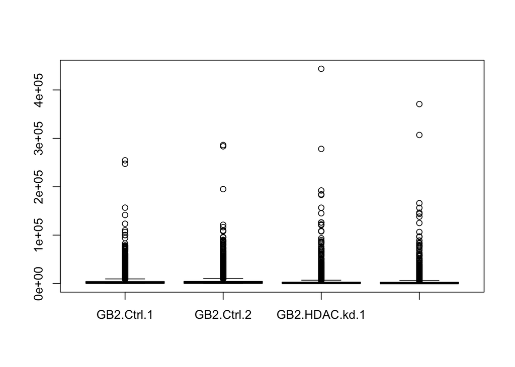

```r
boxplot(GB2_counts) #Quality assesment of the counts
```

```r
#Second GSC
GB11_counts <- read.csv("RNAseq GB11 two replicates")
head(GB11_counts)
```

```
##        X GB11.CT.1 GB11.CT.2 GB11.H7.1 GB11.H7.2
## 1   APC2       248       227       177       148
## 2  EIF3H      2797      2492      3709      4058
## 3  NPHP4       553       545       436       428
## 4 ZNF513       133       135       108       123
## 5 ZNF546        68        35       195       200
## 6   EML1      1736      1515      1603      1682
```

```r
row.names(GB11_counts) = GB11_counts$X
GB11_counts = GB11_counts[, 2:5]
head(GB11_counts)
```

```
##        GB11.CT.1 GB11.CT.2 GB11.H7.1 GB11.H7.2
## APC2         248       227       177       148
## EIF3H       2797      2492      3709      4058
## NPHP4        553       545       436       428
## ZNF513       133       135       108       123
## ZNF546        68        35       195       200
## EML1        1736      1515      1603      1682
```

```r
GB11_counts["HDAC7",]  #Validation of the HDAC7 knocking down
```

```
##       GB11.CT.1 GB11.CT.2 GB11.H7.1 GB11.H7.2
## HDAC7       752       906       302       287
```

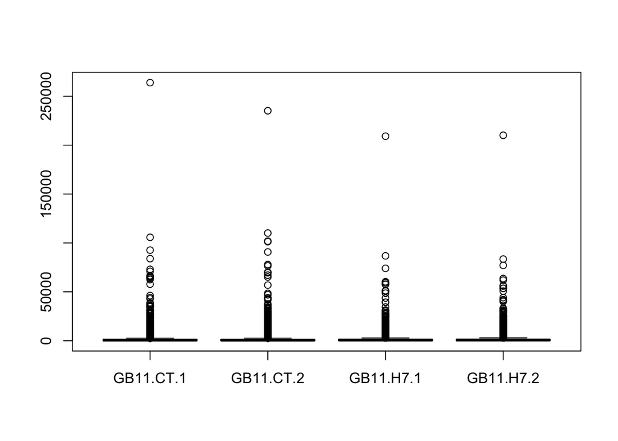

```r
boxplot(GB11_counts)
```

```r
library(dplyr)
library(plyr)
GB24_counts <- read.csv("RNAseq GB24 two replicates")
head(GB24_counts)
```

```
##        X GB24.CT.1 GB24.CT.2 GB24.H7.1 GB24.H7.2
## 1   APC2       185       148       212       185
## 2  EIF3H      3281      2983      3231      2960
## 3  NPHP4       527       427       398       421
## 4 ZNF513       118        91        89        98
## 5 ZNF546       121       124       188       144
## 6   EML1      1445      1309      1335      1237
```

```r
row.names(GB24_counts) = GB24_counts$X
GB24_counts = GB24_counts[, 2:5]
head(GB24_counts)
```

```
##        GB24.CT.1 GB24.CT.2 GB24.H7.1 GB24.H7.2
## APC2         185       148       212       185
## EIF3H       3281      2983      3231      2960
## NPHP4        527       427       398       421
## ZNF513       118        91        89        98
## ZNF546       121       124       188       144
## EML1        1445      1309      1335      1237
```

```r
GB24_counts["HDAC7",] #Validation of the HDAC7 knocking down
```

```
##       GB24.CT.1 GB24.CT.2 GB24.H7.1 GB24.H7.2
## HDAC7       860       673       311       286
```

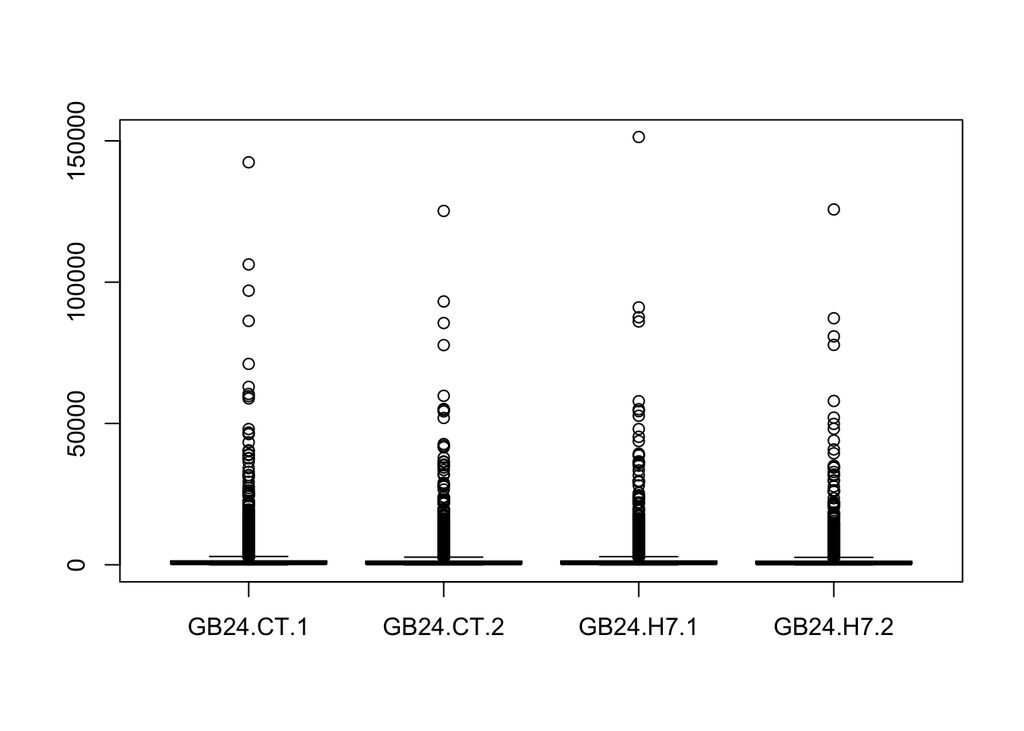

```r
boxplot(GB24_counts)
```

## 2. Design the metadata for each GSC and assign the experimental design

```r
#GB2
exp.des_GB2 <- factor(c("Ctrl", "Ctrl", "Kd", "Kd"))
names(exp.des_GB2) <- colnames(GB2_counts)
type = rep('GSC')

metadata_GB2 = data.frame(colnames(GB2_counts), type, exp.des_GB2,  row.names=NULL)
#write.csv(metadata_GB2, file = 'metadata_GB2.csv')



#GB11
exp.des_GB11 <- factor(c("Ctrl", "Ctrl", "Kd","Kd"))
names(exp.des_GB11) <- colnames(GB11_counts)
type = rep('GSC')

metadata_GB11= data.frame(colnames(GB11_counts), type, exp.des_GB11,  row.names=NULL)
#write.csv(metadata_GB11, file = 'metadata_GB11.csv')

# GB24

exp.des_GB24 <- factor(c("Ctrl", "Ctrl","Kd","Kd"))
names(exp.des_GB24) <- colnames(GB24_counts)
type = rep('GSC')

metadata_GB24= data.frame(colnames(GB24_counts), type, exp.des_GB24,  row.names=NULL)
#write.csv(metadata_GB24, file = 'metadata_GB24.csv')
```

## 3. Differential Expression Analysis

```r
library(DESeq2)
```

### 3.1 DESeq2 Model

```r
# Construct DESEQDataSet Object

#GB2
DEseq_GB2 <- DESeqDataSetFromMatrix(countData=GB2_counts,
                              colData= metadata_GB2,
                              design=~exp.des_GB2)
DEseq_GB2
```

```
## class: DESeqDataSet
## dim: 11818 4
## metadata(1): version
## assays(1): counts
## rownames(11818): CACNB4 MGAT2 ... UBP1 RBM39
## rowData names(0):
## colnames(4): GB2.Ctrl.1 GB2.Ctrl.2 GB2.HDAC.kd.1 GB2.HDAC.kd.2
## colData names(3): colnames.GB2_counts. type exp.des_GB2
```

```r
#GB11
DEseq_GB11 <- DESeqDataSetFromMatrix(countData=GB11_counts,
                              colData= metadata_GB11,
                              design=~exp.des_GB11)
DEseq_GB11
```

```
## class: DESeqDataSet
## dim: 9898 4
## metadata(1): version
## assays(1): counts
## rownames(9898): APC2 EIF3H ... SLC4A7 ZNF431
## rowData names(0):
## colnames(4): GB11.CT.1 GB11.CT.2 GB11.H7.1 GB11.H7.2
## colData names(3): colnames.GB11_counts. type exp.des_GB11
```

```r
#GB24
DEseq_GB24 <- DESeqDataSetFromMatrix(countData=GB24_counts,
                              colData= metadata_GB24,
                              design=~exp.des_GB24)
DEseq_GB24
```

```
## class: DESeqDataSet
## dim: 9898 4
## metadata(1): version
## assays(1): counts
## rownames(9898): APC2 EIF3H ... SLC4A7 ZNF431
## rowData names(0):
## colnames(4): GB24.CT.1 GB24.CT.2 GB24.H7.1 GB24.H7.2
## colData names(3): colnames.GB24_counts. type exp.des_GB24
```

### Now run DESEQ function

```r
dds_GB2 <- DESeq(DEseq_GB2)
dds_GB11 <- DESeq(DEseq_GB11)
dds_GB24 <- DESeq(DEseq_GB24)
```

### 3.2 Extracting differential expression results

The results table reports each gene’s mean normalized count, estimated log2 fold change, standard error, Wald test statistic, p-value, and adjusted p-value. Positive log2 fold changes indicate higher expression following HDAC7 knockdown, while negative values indicate lower expression.

```r
##Take a look at the results table



#### The first GSC "GB2"

#GB2 Kd Vs Ctrl
res_GB2 <- results(dds_GB2)
head(res_GB2, tidy=TRUE)
```

```
## log2 fold change (MLE): exp.des GB2 Kd vs Ctrl
## Wald test p-value: exp.des GB2 Kd vs Ctrl
## DataFrame with 6 rows and 6 columns
##                 baseMean     log2FoldChange             lfcSE              stat
##                <numeric>          <numeric>         <numeric>         <numeric>
## CACNB4  436.217628166468  0.174049393797516 0.289161845608165 0.601909956105915
## MGAT2   1151.94014623811  0.554089246384694 0.208606033186311  2.65615158833792
## ZDHHC18 1473.46953750937 -0.403803701166405 0.199986651294656 -2.01915327124234
## CFLAR   4711.81145516675   0.19495462150192 0.190973242316043  1.02084783783106
## DPY19L3 4561.62651593782  0.759387395342831 0.192232841293466  3.95035203263492
## AGO3    2730.35511411362 0.0793484716346332 0.205196740442481 0.386694600818358
##                       pvalue                 padj
##                    <numeric>            <numeric>
## CACNB4     0.547234076613471    0.633195283409029
## MGAT2    0.00790380767258247   0.0174169679423046
## ZDHHC18   0.0434712914421428   0.0766837075008766
## CFLAR      0.307326535730219    0.397790336755935
## DPY19L3 7.80363299093258e-05 0.000279345080871214
## AGO3       0.698982313732095    0.765222138368309
```

```r
# Examining with more strict Padj,
res_GB2_Sig_0.05 <- subset(res_GB2, padj < 0.05)

res_GB2_Sig_0.01 <- subset(res_GB2, padj < 0.01)
res_GB2_Sig_0.001 <- subset(res_GB2, padj < 0.001)
res_GB2_Sig_0.0001 <- subset(res_GB2, padj < 0.0001)


nrow(res_GB2_Sig_0.01) # no. of diff expressed genes at FDR, 0.01 = 4963
```

```
## [1] 4963
```

```r
# GB2 Doing a filtering at FDR < 0.05 for Kd Vs Ctrl
res_GB2_Sig_0.05 <- subset(res_GB2, padj < 0.05)
nrow(res_GB2_Sig_0.05) # no. of diff expressed genes at FDR, 0.01 = 6270
```

```
## [1] 6270
```

```r
# Save the most diff expressed genes- GB2 "FDR,0.01"
#write.csv(res_GB2_Sig_0.01, file= "Diffexpress_GB2_Sig_0.01_KD~Ctrl.csv", row.names = T)

# Save the most diff expressed genes- GB2 "FDR,0.05"
#write.csv(res_GB2_Sig_0.05, file= "Diffexpress_GB2_Sig_0.05_KD~Ctrl.csv", row.names = T)


# and the downregulated genes by the HDAC7 KD
res_GB2_Sig_0.05_down <- subset(res_GB2_Sig_0.05, log2FoldChange < 0)
nrow(res_GB2_Sig_0.05_down) # no. of diff expressed genes at FDR, 0.01 = 3150
```

```
## [1] 3150
```

```r
head(res_GB2_Sig_0.05_down)
```

```
## log2 fold change (MLE): exp.des GB2 Kd vs Ctrl
## Wald test p-value: exp.des GB2 Kd vs Ctrl
## DataFrame with 6 rows and 6 columns
##                baseMean     log2FoldChange             lfcSE              stat
##               <numeric>          <numeric>         <numeric>         <numeric>
## GRPEL1 1366.10497754931 -0.938272565362148 0.212033715367261 -4.42511024125091
## ZNF408 982.267569854825  -2.26747632843145 0.271431010752235 -8.35378508206354
## DNAH12 600.050298650906  -1.77697963584767 0.250694626902189  -7.0882238594646
## TRAIP  437.851157355363   -2.2589048675769 0.281212830105346 -8.03272335309411
## MCM5    936.17863321111  -1.54878676122786 0.231479911241522 -6.69080419515061
## CEMIP2 1515.92126316051  -1.10212781319465 0.197245800747178 -5.58758568760262
##                      pvalue                 padj
##                   <numeric>            <numeric>
## GRPEL1 9.63930453071665e-06 4.18045141078933e-05
## ZNF408 6.61095855741078e-17 1.93866769805163e-15
## DNAH12 1.35844109687181e-12  2.0529484504899e-11
## TRAIP  9.53324681517638e-16 2.35698558288189e-14
## MCM5   2.21947474133055e-11 2.70968517490129e-10
## CEMIP2 2.30248157050124e-08 1.67244789183674e-07
```

```r
# Save the down regulated Kd/CTRL- GB2 "FDR,0.05"
#write.csv(res_GB2_Sig_0.05_down, file= "Downregulated_GB2_Sig_0.05_KD~Ctrl.csv", row.names = T)






#### The second GSC "GB11"
#GSCs Kd Vs Ctrl
res_GB11 <- results(dds_GB11)
head(res_GB11, tidy=TRUE)
```

```
## log2 fold change (MLE): exp.des GB11 Kd vs Ctrl
## Wald test p-value: exp.des GB11 Kd vs Ctrl
## DataFrame with 6 rows and 6 columns
##                baseMean     log2FoldChange             lfcSE               stat
##               <numeric>          <numeric>         <numeric>          <numeric>
## APC2   199.146461828303 -0.499494163037941  0.27102922014303  -1.84295317963998
## EIF3H  3265.12741380323  0.598615709324121 0.178534380166369   3.35294361100811
## NPHP4  488.534147164841 -0.299543156379786 0.210746781118175  -1.42134154927765
## ZNF513 124.240619277203 -0.169962573005299 0.305298152657636 -0.556710125907301
## ZNF546 125.404565576518   1.98306920050288 0.355501144485128   5.57823577016878
## EML1   1630.37568536804 0.0598344850033541 0.186257170500738  0.321246612103543
##                      pvalue                 padj
##                   <numeric>            <numeric>
## APC2     0.0653358467756908    0.104221468394164
## EIF3H  0.000799569948009109  0.00249107439263272
## NPHP4      0.15521749003812    0.211792489164228
## ZNF513    0.577725497412912    0.636480481733989
## ZNF546 2.42970192898831e-08 2.10334371069364e-07
## EML1      0.748023511179323    0.791949589651614
```

```r
# GB11 Doing a filtering at FDR < 0.05 for Kd Vs Ctrl
res_GB11_Sig_0.05 <- subset(res_GB11, padj < 0.05)
nrow(res_GB11_Sig_0.05)
```

```
## [1] 5284
```

```r
# no. of diff expressed genes at FDR, 0.05 = 5284

# GB11 Doing a filtering at FDR < 0.01 for Kd Vs Ctrl
res_GB11_Sig_0.01 <- subset(res_GB11, padj < 0.01)
res_GB11_Sig_0.001 <- subset(res_GB11, padj < 0.001)
res_GB11_Sig_0.0001 <- subset(res_GB11, padj < 0.0001)


nrow(res_GB11_Sig_0.01) # no. of diff expressed genes at FDR, 0.01 = 3907
```

```
## [1] 3907
```

```r
#and with the strongest upregulation
tail( res_GB11_Sig_0.01[ order( res_GB11_Sig_0.01$log2FoldChange ), ] )
```

```
## log2 fold change (MLE): exp.des GB11 Kd vs Ctrl
## Wald test p-value: exp.des GB11 Kd vs Ctrl
## DataFrame with 6 rows and 6 columns
##                 baseMean   log2FoldChange             lfcSE             stat
##                <numeric>        <numeric>         <numeric>        <numeric>
## SEMA3C   1098.3540155027 2.28491169802433 0.232907726628941 9.81037310825053
## ZNF449  104.316081427235   2.294036360967 0.350310876217547 6.54857304385371
## SPARCL1 57.2258345445457 2.36094378239303 0.449980335466769 5.24677101710233
## CP      268.686076641029  2.4020971695438 0.272771082042507  8.8062750331044
## FGD4    816.138279910855 2.43201051580106 0.266444949221167  9.1276285135446
## ST8SIA4  1029.7379672784 2.49053886606741 0.236500106658724  10.530814980398
##                       pvalue                 padj
##                    <numeric>            <numeric>
## SEMA3C  1.01592223605981e-22    5.02779914626e-19
## ZNF449  5.80894434408408e-11 1.17101692704163e-09
## SPARCL1 1.54788084843239e-07 1.11424906456609e-06
## CP      1.29373373821923e-18 1.82933950584199e-15
## FGD4    7.00161688481412e-20 2.31006679752967e-16
## ST8SIA4 6.22927999484771e-26 6.16574133890026e-22
```

```r
# Save the most diff expressed genes- GB11 "FDR,0.01"
write.csv(res_GB11_Sig_0.01, file= "Diffexpress_GB11_Sig_0.01_KD~Ctrl.csv", row.names = T)

# Save the most diff expressed genes- GB11 "FDR,0.05"
write.csv(res_GB11_Sig_0.05, file= "Diffexpress_GB11_Sig_0.05_KD~Ctrl.csv", row.names = T)


# and the downregulated genes by the HDAC7 KD
res_GB11_Sig_0.05_down <- subset(res_GB11_Sig_0.05, log2FoldChange < 0)
nrow(res_GB11_Sig_0.05_down) # no. of diff expressed genes at FDR, 0.01 = 1870
```

```
## [1] 1870
```

```r
head(res_GB11_Sig_0.05_down)
```

```
## log2 fold change (MLE): exp.des GB11 Kd vs Ctrl
## Wald test p-value: exp.des GB11 Kd vs Ctrl
## DataFrame with 6 rows and 6 columns
##                 baseMean     log2FoldChange             lfcSE              stat
##                <numeric>          <numeric>         <numeric>         <numeric>
## HS1BP3  309.987274438328 -0.622833129058445 0.245225882566485 -2.53983438672949
## TMEM205 336.886313662307 -0.612291307080954 0.230639670244239 -2.65475278573092
## TBCB    985.921809161381 -0.968845861401002 0.204255274676268 -4.74330889587337
## FAIM2   320.827803856271 -0.990846473140684 0.252973305648653 -3.91680248870543
## FLYWCH1 764.029152015616 -0.478682695181518 0.210381206718478 -2.27531110144295
## ESS2    238.169908379025  -0.84240298335132 0.257902279874951 -3.26636501142904
##                       pvalue                 padj
##                    <numeric>            <numeric>
## HS1BP3    0.0110904971291256   0.0239890167360326
## TMEM205   0.0079366549167769   0.0180965239268044
## TBCB    2.10255289011814e-06 1.16327940225765e-05
## FAIM2   8.97312059380575e-05 0.000350497030929318
## FLYWCH1   0.0228872739533793   0.0441079123034556
## ESS2     0.00108937731721125  0.00329040484765241
```

```r
# Save the down regulated Kd/CTRL- GB2 "FDR,0.05"
write.csv(res_GB11_Sig_0.05_down, file= "Downregulated_GB11_Sig_0.05_KD~Ctrl.csv", row.names = T)





#### The third GSC "GB24"
#GB24 Kd Vs Ctrl
res_GB24 <- results(dds_GB24)
head(res_GB24, tidy=TRUE)
```

```
## log2 fold change (MLE): exp.des GB24 Kd vs Ctrl
## Wald test p-value: exp.des GB24 Kd vs Ctrl
## DataFrame with 6 rows and 6 columns
##                baseMean      log2FoldChange             lfcSE
##               <numeric>           <numeric>         <numeric>
## APC2    182.15978230489   0.317683715111682 0.197168065193878
## EIF3H  3107.68996433088  0.0453892058505598 0.058214953263159
## NPHP4  441.777748600109  -0.151454699635883 0.136078328510688
## ZNF513  98.706748494873 -0.0900178742101793 0.268704248295453
## ZNF546 144.280710073377   0.493641636662325 0.224435698879666
## EML1   1328.20868832284 -0.0359770352542445 0.079193911394677
##                      stat             pvalue              padj
##                 <numeric>          <numeric>         <numeric>
## APC2     1.61123311120033   0.10712892348134 0.355230179101608
## EIF3H   0.779682938941465  0.435577523575728  0.74203128347012
## NPHP4   -1.11299647264544   0.26570994442664 0.582502110727548
## ZNF513 -0.335007260887072  0.737619609001592 0.908075847635176
## ZNF546   2.19947913423077 0.0278438712090521 0.143990928540855
## EML1   -0.454290419814555  0.649619810498125  0.87277266137403
```

```r
nrow(res_GB24)
```

```
## [1] 9898
```

```r
# GB24 Doing a filtering at FDR < 0.05 for Kd Vs Ctrl
res_GB24_Sig_0.05 <- subset(res_GB24, padj < 0.05)
nrow(res_GB24_Sig_0.05)
```

```
## [1] 1342
```

```r
# GB24 Doing a filtering at FDR < 0.01 for Kd Vs Ctrl
res_GB24_Sig_0.01 <- subset(res_GB24, padj < 0.01)
res_GB24_Sig_0.001 <- subset(res_GB24, padj < 0.001)
res_GB24_Sig_0.0001 <- subset(res_GB24, padj < 0.0001)

nrow(res_GB24_Sig_0.01) # no. of diff expressed genes at FDR, 0.05 = 918
```

```
## [1] 918
```

```r
#and with the strongest upregulation
tail( res_GB24_Sig_0.01[ order( res_GB24_Sig_0.01$log2FoldChange ), ] )
```

```
## log2 fold change (MLE): exp.des GB24 Kd vs Ctrl
## Wald test p-value: exp.des GB24 Kd vs Ctrl
## DataFrame with 6 rows and 6 columns
##                baseMean   log2FoldChange             lfcSE             stat
##               <numeric>        <numeric>         <numeric>        <numeric>
## CMYA5  244.073390227175 1.12789411802245 0.172859375835968  6.5249230050023
## SAMD9L 805.944606951148 1.16687960005975 0.100772208769567  11.579379020341
## SAMD9  700.302308195822 1.19644440060883 0.111367116211728 10.7432466719725
## OMD    310.474082017209 1.20265055933295 0.157083907092771   7.656102917167
## RNH1   129.722342487036 1.37232446460687 0.248503100855377 5.52236354348564
## ACACA  523.589795731935 1.61398840155575 0.132119356262309 12.2161388551678
##                      pvalue                 padj
##                   <numeric>            <numeric>
## CMYA5  6.80364749076348e-11  4.1827641530172e-09
## SAMD9L 5.24244248502384e-31 3.99151505513584e-28
## SAMD9  6.37618650394399e-27 3.00530923885893e-24
## OMD    1.91660150638899e-14 2.37131521377977e-12
## RNH1    3.3446953990703e-08 1.25877547756646e-06
## ACACA  2.54906707166911e-34 2.52306658753809e-31
```

```r
# Save the most diff expressed genes- GB24 "FDR,0.05"
write.csv(res_GB24_Sig_0.05, file= "Diffexpress_GB24_Sig_0.05_KD~Ctrl.csv", row.names = T)

# Save the most diff expressed genes- GB24 "FDR,0.01"
write.csv(res_GB24_Sig_0.01, file= "Diffexpress_GB24_Sig_0.01_KD~Ctrl.csv", row.names = T)


# and the downregulated genes by the HDAC7 KD
res_GB24_Sig_0.05_down <- subset(res_GB24_Sig_0.05, log2FoldChange < 0)
nrow(res_GB24_Sig_0.05_down) # no. of diff expressed genes at FDR, 0.01 = 607
```

```
## [1] 607
```

```r
head(res_GB24_Sig_0.05_down)
```

```
## log2 fold change (MLE): exp.des GB24 Kd vs Ctrl
## Wald test p-value: exp.des GB24 Kd vs Ctrl
## DataFrame with 6 rows and 6 columns
##                 baseMean     log2FoldChange              lfcSE
##                <numeric>          <numeric>          <numeric>
## TBCB    864.805464498965 -0.299219842426245  0.100915969486713
## TMEM30A 1459.45149427771 -0.497284390084288 0.0845448755491259
## POFUT2  1538.96280654668 -0.259823750111952 0.0841806574369825
## RPL27   6828.00623909749 -0.155062888622017 0.0547177438228338
## KPNA6   2905.64554985389 -0.192357819708214 0.0647023125935379
## SCARB2  2876.74527332093 -0.378600467748749 0.0607155247941488
##                      stat               pvalue                 padj
##                 <numeric>            <numeric>            <numeric>
## TBCB    -2.96503956656377  0.00302644002405239   0.0262309136235294
## TMEM30A  -5.8818986586045 4.05586662525876e-09 1.74543338507875e-07
## POFUT2  -3.08650179296183  0.00202526725209555   0.0188757959145403
## RPL27   -2.83386846365747  0.00459882570258423   0.0369473837696256
## KPNA6   -2.97296668384346  0.00294936463217529   0.0256302117026084
## SCARB2  -6.23564515059969 4.49919944743364e-10 2.38144792142771e-08
```

```r
# Save the down regulated Kd/CTRL- GB2 "FDR,0.05"
write.csv(res_GB24_Sig_0.05_down, file= "Downregulated_GB24_Sig_0.05_KD~Ctrl.csv", row.names = T)
```

### Summary of differential gene expression

```r
summary(res_GB2_Sig_0.05)
```

```
##
## out of 6270 with nonzero total read count
## adjusted p-value < 0.1
## LFC > 0 (up)       : 3120, 50%
## LFC < 0 (down)     : 3150, 50%
## outliers [1]       : 0, 0%
## low counts [2]     : 0, 0%
## (mean count < 28)
## [1] see 'cooksCutoff' argument of ?results
## [2] see 'independentFiltering' argument of ?results
```

```r
summary(res_GB11_Sig_0.05)
```

```
##
## out of 5284 with nonzero total read count
## adjusted p-value < 0.1
## LFC > 0 (up)       : 3414, 65%
## LFC < 0 (down)     : 1870, 35%
## outliers [1]       : 0, 0%
## low counts [2]     : 0, 0%
## (mean count < 13)
## [1] see 'cooksCutoff' argument of ?results
## [2] see 'independentFiltering' argument of ?results
```

```r
summary(res_GB24_Sig_0.05)
```

```
##
## out of 1342 with nonzero total read count
## adjusted p-value < 0.1
## LFC > 0 (up)       : 735, 55%
## LFC < 0 (down)     : 607, 45%
## outliers [1]       : 0, 0%
## low counts [2]     : 0, 0%
## (mean count < 13)
## [1] see 'cooksCutoff' argument of ?results
## [2] see 'independentFiltering' argument of ?results
```

```r
summary(res_GB2_Sig_0.01)
```

```
##
## out of 4963 with nonzero total read count
## adjusted p-value < 0.1
## LFC > 0 (up)       : 2434, 49%
## LFC < 0 (down)     : 2529, 51%
## outliers [1]       : 0, 0%
## low counts [2]     : 0, 0%
## (mean count < 28)
## [1] see 'cooksCutoff' argument of ?results
## [2] see 'independentFiltering' argument of ?results
```

```r
summary(res_GB11_Sig_0.01)
```

```
##
## out of 3907 with nonzero total read count
## adjusted p-value < 0.1
## LFC > 0 (up)       : 3029, 78%
## LFC < 0 (down)     : 878, 22%
## outliers [1]       : 0, 0%
## low counts [2]     : 0, 0%
## (mean count < 13)
## [1] see 'cooksCutoff' argument of ?results
## [2] see 'independentFiltering' argument of ?results
```

```r
summary(res_GB24_Sig_0.01)
```

```
##
## out of 918 with nonzero total read count
## adjusted p-value < 0.1
## LFC > 0 (up)       : 512, 56%
## LFC < 0 (down)     : 406, 44%
## outliers [1]       : 0, 0%
## low counts [2]     : 0, 0%
## (mean count < 13)
## [1] see 'cooksCutoff' argument of ?results
## [2] see 'independentFiltering' argument of ?results
```

```r
summary(res_GB2_Sig_0.001)
```

```
##
## out of 3793 with nonzero total read count
## adjusted p-value < 0.1
## LFC > 0 (up)       : 1837, 48%
## LFC < 0 (down)     : 1956, 52%
## outliers [1]       : 0, 0%
## low counts [2]     : 0, 0%
## (mean count < 28)
## [1] see 'cooksCutoff' argument of ?results
## [2] see 'independentFiltering' argument of ?results
```

```r
summary(res_GB11_Sig_0.001)
```

```
##
## out of 2836 with nonzero total read count
## adjusted p-value < 0.1
## LFC > 0 (up)       : 2556, 90%
## LFC < 0 (down)     : 280, 9.9%
## outliers [1]       : 0, 0%
## low counts [2]     : 0, 0%
## (mean count < 13)
## [1] see 'cooksCutoff' argument of ?results
## [2] see 'independentFiltering' argument of ?results
```

```r
summary(res_GB24_Sig_0.001)
```

```
##
## out of 607 with nonzero total read count
## adjusted p-value < 0.1
## LFC > 0 (up)       : 339, 56%
## LFC < 0 (down)     : 268, 44%
## outliers [1]       : 0, 0%
## low counts [2]     : 0, 0%
## (mean count < 13)
## [1] see 'cooksCutoff' argument of ?results
## [2] see 'independentFiltering' argument of ?results
```

### Identify mutual differentially expressed genes across the 3 GSC models for FDR <0.05

```r
# Diff expressed Sign. genes for GB2
sign_DESeq_GB2_0.05 <- res_GB2[res_GB2$padj<0.05,]# 6270 genes out of 11818
nrow(sign_DESeq_GB2_0.05)
```

```
## [1] 6270
```

```r
head(sign_DESeq_GB2_0.05)
```

```
## log2 fold change (MLE): exp.des GB2 Kd vs Ctrl
## Wald test p-value: exp.des GB2 Kd vs Ctrl
## DataFrame with 6 rows and 6 columns
##                 baseMean     log2FoldChange             lfcSE              stat
##                <numeric>          <numeric>         <numeric>         <numeric>
## MGAT2   1151.94014623811  0.554089246384694 0.208606033186311  2.65615158833792
## DPY19L3 4561.62651593782  0.759387395342831 0.192232841293466  3.95035203263492
## PCSK4   121.943125268497   1.33621676738244 0.469190107487857  2.84792186803943
## GRPEL1  1366.10497754931 -0.938272565362148 0.212033715367261 -4.42511024125091
## SHC1    4211.20988954607  0.976604748687976 0.179502424053277  5.44062150602553
## ZNF408  982.267569854825  -2.26747632843145 0.271431010752235 -8.35378508206354
##                       pvalue                 padj
##                    <numeric>            <numeric>
## MGAT2    0.00790380767258247   0.0174169679423046
## DPY19L3 7.80363299093258e-05 0.000279345080871214
## PCSK4    0.00440057267937458   0.0104178621644328
## GRPEL1  9.63930453071665e-06 4.18045141078933e-05
## SHC1    5.30950118792151e-08 3.62284555651596e-07
## ZNF408  6.61095855741078e-17 1.93866769805163e-15
```

```r
sign_DESeq_GB2_0.05[order(sign_DESeq_GB2_0.05$padj), ]
```

```
## log2 fold change (MLE): exp.des GB2 Kd vs Ctrl
## Wald test p-value: exp.des GB2 Kd vs Ctrl
## DataFrame with 6270 rows and 6 columns
##                  baseMean     log2FoldChange             lfcSE
##                 <numeric>          <numeric>         <numeric>
## ICAM1    1985.92449836043  -4.93746005507219 0.225775790118096
## CSRNP1   8971.71094632494  -4.12281786720911 0.217944682569563
## PPP1R15A 28414.8960595535  -4.42411046947899 0.243867425101744
## NR1D1    26928.0018522543  -4.55257163986799 0.251867407095168
## TNFAIP3  10637.6307278973  -3.16425483767649   0.1791423340304
## ...                   ...                ...               ...
## BOD1     955.525810110652 -0.502688425271847 0.226405124290821
## AJM1     701.646147245466 -0.508781909452254 0.229216936196988
## LEMD3      2453.787640574 -0.421449106054374 0.189909927019498
## EXOSC5   293.957559591472 -0.662834670518521 0.298713995468308
## CACNG7   54.3257474285409   1.37839372083747 0.621246553978316
##                       stat                pvalue                  padj
##                  <numeric>             <numeric>             <numeric>
## ICAM1    -21.8688640287321 5.14218203736078e-106 6.07703073175297e-102
## CSRNP1   -18.9168086993506  8.29260608992693e-80  4.90010093853782e-76
## PPP1R15A -18.1414572595467   1.5000061043302e-73  5.90902404699144e-70
## NR1D1    -18.0752710022055  4.99095403145999e-73  1.47457736859486e-69
## TNFAIP3  -17.6633560950452  8.03188116766442e-70  1.89841543278916e-66
## ...                    ...                   ...                   ...
## BOD1     -2.22030498137549    0.0263980720204084    0.0497957456952198
## AJM1     -2.21965234285747    0.0264423762208997    0.0498637310002542
## LEMD3    -2.21920524465845    0.0264727644353245    0.0499130711704954
## EXOSC5   -2.21896088088997    0.0264893860145895    0.0499364434392118
## CACNG7    2.21875471503313    0.0265034163901995     0.049954924226376
```

```r
GB2_all_diff_expressed =sign_DESeq_GB2_0.05[order(sign_DESeq_GB2_0.05$log2FoldChange), ]


# Diff expressed Sign. genes for GB11
sign_DESeq_GB11_0.05 <- res_GB11[res_GB11$padj<0.05,]#  3656
nrow(sign_DESeq_GB11_0.05)
```

```
## [1] 5284
```

```r
head(sign_DESeq_GB11_0.05)
```

```
## log2 fold change (MLE): exp.des GB11 Kd vs Ctrl
## Wald test p-value: exp.des GB11 Kd vs Ctrl
## DataFrame with 6 rows and 6 columns
##                baseMean    log2FoldChange             lfcSE             stat
##               <numeric>         <numeric>         <numeric>        <numeric>
## EIF3H  3265.12741380323 0.598615709324121 0.178534380166369 3.35294361100811
## ZNF546 125.404565576518  1.98306920050288 0.355501144485128 5.57823577016878
## ZNF84   667.72622613727  1.90749461439412 0.229647706917728  8.3061774924558
## DENR   1314.72583056628 0.748299336846944  0.18922839456641 3.95447701472904
## CLASP2 906.984394275192  1.70378737168207 0.232497359624272 7.32820095004726
## CLIC4   7033.6859897963  1.50215770932779 0.211690546083976 7.09600753135142
##                      pvalue                 padj
##                   <numeric>            <numeric>
## EIF3H  0.000799569948009109  0.00249107439263272
## ZNF546 2.42970192898831e-08 2.10334371069364e-07
## ZNF84  9.88343611791765e-17 5.75448533500876e-14
## DENR   7.67022448765927e-05 0.000303679527915406
## CLASP2 2.33262781586592e-13 1.51897040272637e-11
## CLIC4   1.2841248286425e-12 5.35503964327701e-11
```

```r
sign_DESeq_GB11_0.05[order(sign_DESeq_GB11_0.05$padj), ]
```

```
## log2 fold change (MLE): exp.des GB11 Kd vs Ctrl
## Wald test p-value: exp.des GB11 Kd vs Ctrl
## DataFrame with 5284 rows and 6 columns
##                  baseMean     log2FoldChange             lfcSE
##                 <numeric>          <numeric>         <numeric>
## ST8SIA4   1029.7379672784   2.49053886606741 0.236500106658724
## SEMA3C    1098.3540155027   2.28491169802433 0.232907726628941
## FGD4     816.138279910855   2.43201051580106 0.266444949221167
## MECOM    2121.43437359859   1.97585162414783 0.217404990337755
## SERPINE1 3924.92969210453  -1.56317884808449 0.173079110562184
## ...                   ...                ...               ...
## FANCG     328.59317874375 -0.512516700926579  0.23110246436831
## NARF     845.125154825766 -0.440306852206639 0.198595096908569
## ASTN2    551.162949142158 -0.463746419505327 0.209210290909486
## TOMM34   2020.92295258643 -0.428811588479933 0.193459280081067
## INTS5    570.923382389728 -0.473956048891156 0.213867457136674
##                       stat               pvalue                 padj
##                  <numeric>            <numeric>            <numeric>
## ST8SIA4    10.530814980398 6.22927999484771e-26 6.16574133890026e-22
## SEMA3C    9.81037310825053 1.01592223605981e-22    5.02779914626e-19
## FGD4       9.1276285135446 7.00161688481412e-20 2.31006679752967e-16
## MECOM     9.08834530926912 1.00557725482987e-19 2.48830091707652e-16
## SERPINE1 -9.03158586271373 1.69201676896226e-19  3.3495163958377e-16
## ...                    ...                  ...                  ...
## FANCG    -2.21770331323589   0.0265750682023838   0.0498181865657566
## NARF     -2.21710837307001   0.0266156867665439   0.0498848830932118
## ASTN2    -2.21665204655715   0.0266468780393914   0.0499338884577615
## TOMM34    -2.2165470082399   0.0266540621887879   0.0499378965634341
## INTS5    -2.21612046655733   0.0266832529176194   0.0499831259232773
```

```r
GB11_all_diff_expressed =sign_DESeq_GB11_0.05[order(sign_DESeq_GB11_0.05$log2FoldChange), ]

# Diff expressed Sign. genes for GB24
sign_DESeq_GB24_0.05 <- res_GB24[res_GB24$padj<0.05,]
nrow(sign_DESeq_GB24_0.05)# 1342
```

```
## [1] 1342
```

```r
head(sign_DESeq_GB24_0.05)
```

```
## log2 fold change (MLE): exp.des GB24 Kd vs Ctrl
## Wald test p-value: exp.des GB24 Kd vs Ctrl
## DataFrame with 6 rows and 6 columns
##                 baseMean     log2FoldChange              lfcSE
##                <numeric>          <numeric>          <numeric>
## ZNF84   761.643403728244  0.654304693357793  0.100561068754554
## CLASP2  1117.01359296875  0.254490424335805 0.0933841681392215
## POM121C 2142.85110508859  0.206246677666356 0.0667184128205005
## PPM1L   503.411103511352  0.558128725352313  0.125011626242095
## TBCB    864.805464498965 -0.299219842426245  0.100915969486713
## SYNE1   2840.76366852707  0.256327468413616 0.0604218476814769
##                      stat               pvalue                 padj
##                 <numeric>            <numeric>            <numeric>
## ZNF84    6.50654076633568 7.69010408201232e-11 4.66973314133484e-09
## CLASP2   2.72519881481836  0.00642627776010361   0.0478970611969168
## POM121C  3.09130072115538  0.00199281696681976   0.0186083984316811
## PPM1L    4.46461454930162 8.02130252398501e-06 0.000170375219704729
## TBCB    -2.96503956656377  0.00302644002405239   0.0262309136235294
## SYNE1     4.2422977490673 2.21242895802427e-05  0.00041791263027718
```

```r
sign_DESeq_GB24_0.05[order(sign_DESeq_GB24_0.05$padj), ]
```

```
## log2 fold change (MLE): exp.des GB24 Kd vs Ctrl
## Wald test p-value: exp.des GB24 Kd vs Ctrl
## DataFrame with 1342 rows and 6 columns
##                  baseMean     log2FoldChange              lfcSE
##                 <numeric>          <numeric>          <numeric>
## SERPINE1 2712.50830290572   -1.3212404012857 0.0752926009005897
## TMED2    4272.97850374129 -0.868981091605877 0.0540416052763255
## GOLGB1   2447.35438226606  0.995065791135007 0.0661227353468765
## DST       11894.337121235  0.751615250266237 0.0503304494926159
## NEMP1    1205.87593874666  -1.20862150129556 0.0853237135702269
## ...                   ...                ...                ...
## TSC22D2   892.31639595739 -0.258253782861849 0.0951688599464243
## NUAK1     1191.4785820605  0.226548540179617 0.0835503906611645
## HIVEP1   797.082773702453  0.273702779254377  0.101028282241181
## KIAA1211  203.91969128153   0.50751347554171  0.187397334514599
## POU2F1   2030.73944287069  0.191311113894651 0.0706553618617116
##                       stat               pvalue                 padj
##                  <numeric>            <numeric>            <numeric>
## SERPINE1 -17.5480775731224 6.15276095808388e-69 6.09000279631142e-65
## TMED2    -16.0798534233505 3.53213670229466e-58 1.74805445396563e-54
## GOLGB1    15.0487693213982 3.51716462985101e-51 1.16042985020884e-47
## DST       14.9336089354121 1.99187461336442e-50 4.92889373077025e-47
## NEMP1    -14.1651300760695 1.50587830662553e-45  2.9810366957959e-42
## ...                    ...                  ...                  ...
## TSC22D2  -2.71363745459632   0.0066548953215655   0.0492303093369622
## NUAK1      2.7115198191996  0.00669755370298617    0.049508877186077
## HIVEP1     2.7091698797865  0.00674517929818934    0.049823719920506
## KIAA1211  2.70822142084509  0.00676448752611351    0.049929080934729
## POU2F1    2.70766589900268  0.00677581960138936   0.0499754563446736
```

```r
GB24_all_diff_expressed =sign_DESeq_GB24_0.05[order(sign_DESeq_GB24_0.05$log2FoldChange), ]


# Matches between both:

GSCs_Matches =intersect(row.names(sign_DESeq_GB2_0.05) , row.names(sign_DESeq_GB11_0.05)) # 2893 genes
GSCs_Matches_all =intersect((GSCs_Matches) , row.names(sign_DESeq_GB24_0.05)) #653 genes




write.csv(GSCs_Matches_all, file= "Diffexpress_3 GSCs_Sig_0.05_KD~Ctrl.csv", row.names = T)
```

### 4. QC: PCA and sample validation

**PCA shows clear separation between control and HDAC7-knockdown in the three GSC models**

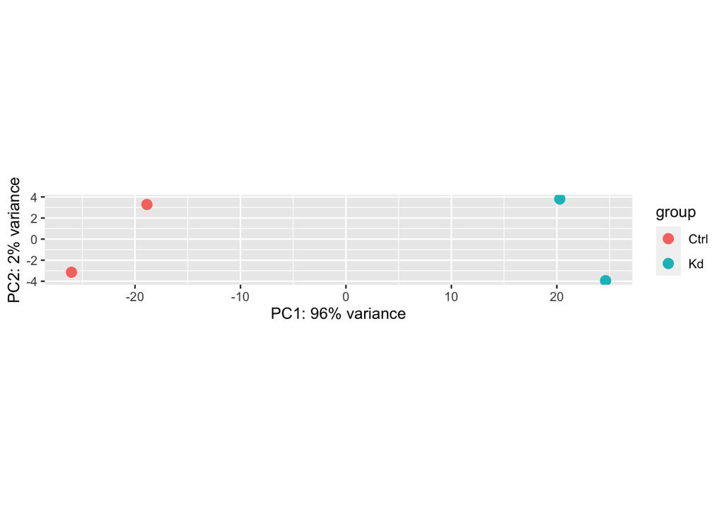

```r
## PCA
#First we need to transform the raw count data
#vst function will perform variance stabilizing transformation


#GB2
vsdata_GB2 <- vst(dds_GB2, blind=FALSE)
plotPCA(vsdata_GB2, intgroup="exp.des_GB2") # using the DESEQ2 plotPCA fxn we can
```

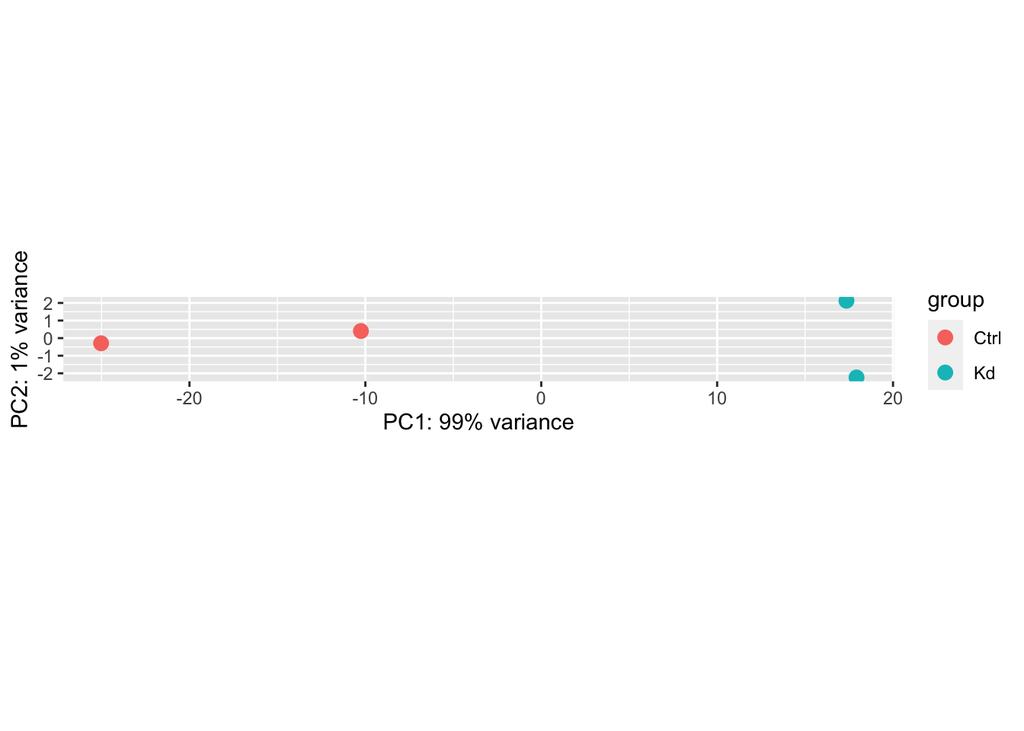

```r
#GB11
vsdata_GB11 <- vst(dds_GB11, blind=FALSE)
plotPCA(vsdata_GB11, intgroup="exp.des_GB11") # using the DESEQ2 plotPCA fxn we can
```

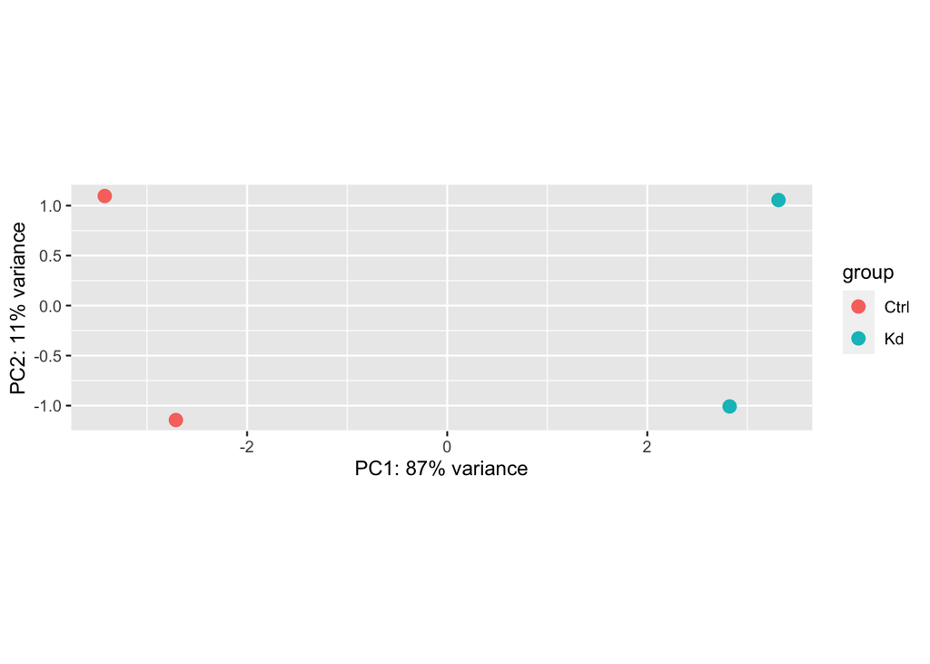

```r
#GB24
vsdata_GB24 <- vst(dds_GB24, blind=FALSE)
plotPCA(vsdata_GB24, intgroup="exp.des_GB24") # using the DESEQ2 plotPCA fxn we can
```

## QC: Sample similarity and hierarchical Clustering

### How similar the samples are across their overall gene expression profiles and whether replicates cluster as expected.

**The sample distance heatmap shows that HDAC7-knockdown samples cluster together and separately from CT samples. Distances within each condition are smaller than those between conditions, indicating greater similarity between replicates than across experimental groups. This pattern supports a consistent transcriptional difference associated with HDAC7 knockdown and complements the separation observed in PCA.**

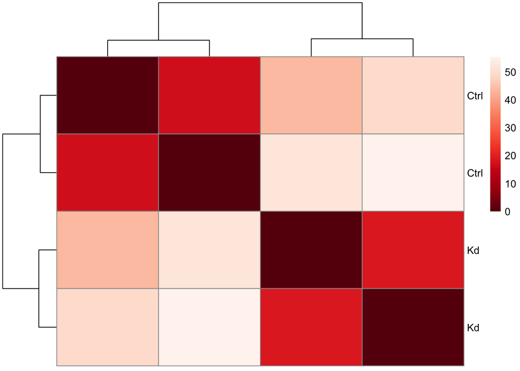

```r
## Load packages
library("pheatmap")
library("RColorBrewer") #vibrant colors

## Do the rlog transformation:

rld_GB2 = rlogTransformation(dds_GB2)
rld_GB11 = rlogTransformation(dds_GB11)
rld_GB24 = rlogTransformation(dds_GB24)


##Clustering the sample-to-sample distances

#GB2
distsRL_GB2 <- dist(t(assay(rld_GB2))) # Calculate distances using transformed (and normalized) counts
mat_GB2 <- as.matrix(distsRL_GB2) # convert to matrix
rownames(mat_GB2) <- colnames(mat_GB2) <- with(colData(dds_GB2), paste(exp.des_GB2)) # set rownames in the matrix
colnames(mat_GB2) = NULL # remove column names
par(ps = 9, cex = 0.8, cex.main = 1)
colors <- colorRampPalette( rev(brewer.pal(9, "Reds")) )(255) # set colors
pheatmap(mat_GB2,
         clustering_distance_rows=distsRL_GB2,
         clustering_distance_cols=distsRL_GB2,
         col=colors)
```

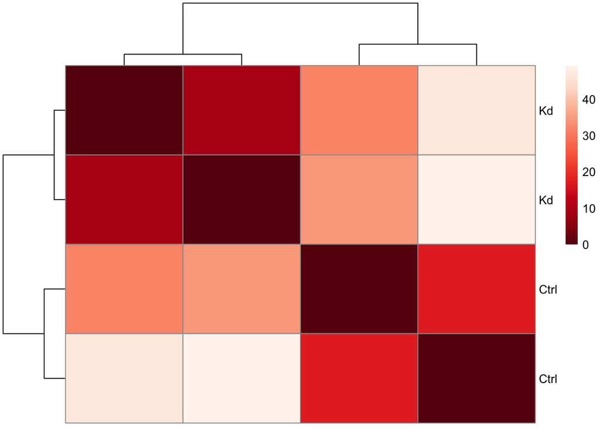

```r
#GB11
distsRL_GB11 <- dist(t(assay(rld_GB11))) # Calculate distances using transformed (and normalized) counts
mat_GB11 <- as.matrix(distsRL_GB11) # convert to matrix
rownames(mat_GB11) <- colnames(mat_GB11) <- with(colData(dds_GB11), paste(exp.des_GB11)) # set rownames in the matrix
colnames(mat_GB11) = NULL # remove column names
par(ps = 9, cex = 0.8, cex.main = 1)
colors <- colorRampPalette( rev(brewer.pal(9, "Reds")) )(255) # set colors
pheatmap(mat_GB11,
         clustering_distance_rows=distsRL_GB11,
         clustering_distance_cols=distsRL_GB11,
         col=colors)
```

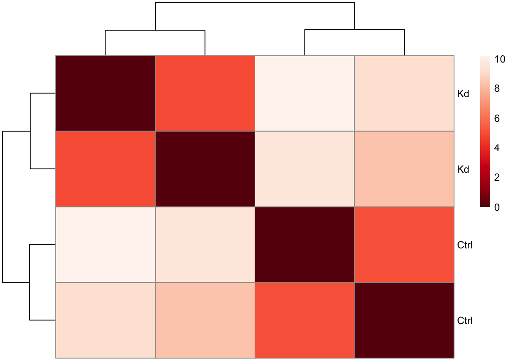

```r
#GB24
distsRL_GB24 <- dist(t(assay(rld_GB24))) # Calculate distances using transformed (and normalized) counts
mat_GB24 <- as.matrix(distsRL_GB24) # convert to matrix
rownames(mat_GB24) <- colnames(mat_GB24) <- with(colData(dds_GB24), paste(exp.des_GB24)) # set rownames in the matrix
colnames(mat_GB24) = NULL # remove column names
par(ps = 9, cex = 0.8, cex.main = 1)
colors <- colorRampPalette( rev(brewer.pal(9, "Reds")) )(255) # set colors
pheatmap(mat_GB24,
         clustering_distance_rows=distsRL_GB24,
         clustering_distance_cols=distsRL_GB24,
         col=colors)
```

## 4. Gene differential expression visualization

### 4.1 Volcano Plot

```r
library(EnhancedVolcano)
```

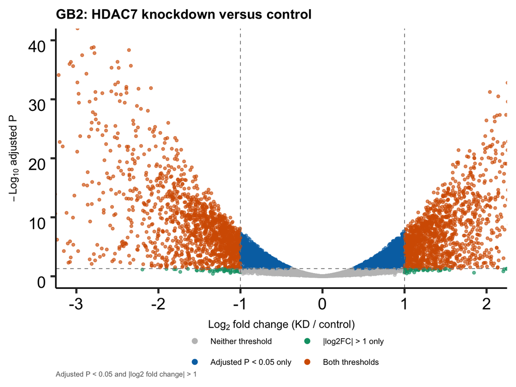

```r
library(ggplot2)

make_volcano <- function(res, model, selected_genes = character(0)) {

  plot_data <- as.data.frame(res)

  plot_data <- plot_data[
    is.finite(plot_data$log2FoldChange) &
      !is.na(plot_data$padj),
  ]

  plot_data$padj <- pmax(
    plot_data$padj,
    .Machine$double.xmin
  )

  EnhancedVolcano(
    plot_data,
    lab = rownames(plot_data),
    x = "log2FoldChange",
    y = "padj",

    title = paste0(model, ": HDAC7 knockdown versus control"),
    subtitle = NULL,
    caption = "Adjusted P < 0.05 and |log2 fold change| > 1",

    xlab = bquote(Log[2] ~ "fold change (KD / control)"),
    ylab = bquote(-Log[10] ~ "adjusted P"),

    pCutoff = 0.05,
    FCcutoff = 1,

    selectLab = selected_genes,
    drawConnectors = length(selected_genes) > 0,
    widthConnectors = 0.4,

    pointSize = 1.3,
    colAlpha = 0.65,
    labSize = 3,

    col = c("grey75", "#009E73", "#0072B2", "#D55E00"),

    legendLabels = c(
      "Neither threshold",
      "|log2FC| > 1 only",
      "Adjusted P < 0.05 only",
      "Both thresholds"
    ),
    legendPosition = "bottom",
    legendLabSize = 9,
    legendIconSize = 2.5,

    titleLabSize = 15,
    captionLabSize = 8,

    cutoffLineType = "dashed",
    cutoffLineCol = "grey50",
    cutoffLineWidth = 0.4,

    gridlines.major = FALSE,
    gridlines.minor = FALSE
  )
}

format_volcano <- function(p) {
  p +
    theme(
      plot.title = element_text(
        size = 15, face = "bold",
        margin = margin(b = 8)
      ),
      axis.title.x = element_text(
        size = 12, margin = margin(t = 8)
      ),
      axis.title.y = element_text(
        size = 12, margin = margin(r = 8)
      ),
      axis.text = element_text(size = 10, color = "black"),

      legend.position = "bottom",
      legend.text = element_text(size = 9),
      legend.key.size = grid::unit(0.4, "cm"),
      legend.margin = margin(0, 0, 0, 0),
      legend.box.spacing = grid::unit(0.15, "cm"),

      plot.caption = element_text(
        size = 8, hjust = 0,
        color = "grey40",
        margin = margin(t = 5)
      ),
      plot.margin = margin(10, 10, 10, 10)
    ) +
  coord_cartesian(
    xlim = c(-3, 2),
    ylim = c(0, 40)
  ) +
    guides(
      colour = guide_legend(
        nrow = 2,
        byrow = TRUE,
        override.aes = list(size = 2.5, alpha = 1)
      )
    )
}

# Full, unfiltered DESeq2 results
p_GB2  <- format_volcano(make_volcano(res_GB2, "GB2"))
p_GB11 <- format_volcano(make_volcano(res_GB11, "GB11"))
p_GB24 <- format_volcano(make_volcano(res_GB24, "GB24"))

print(p_GB2)
```

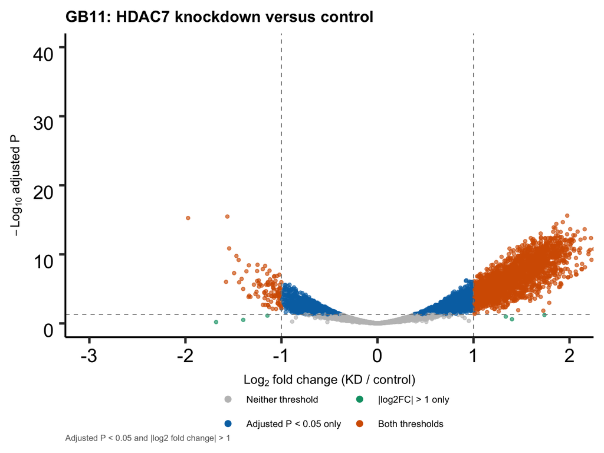

```r
print(p_GB11)
```

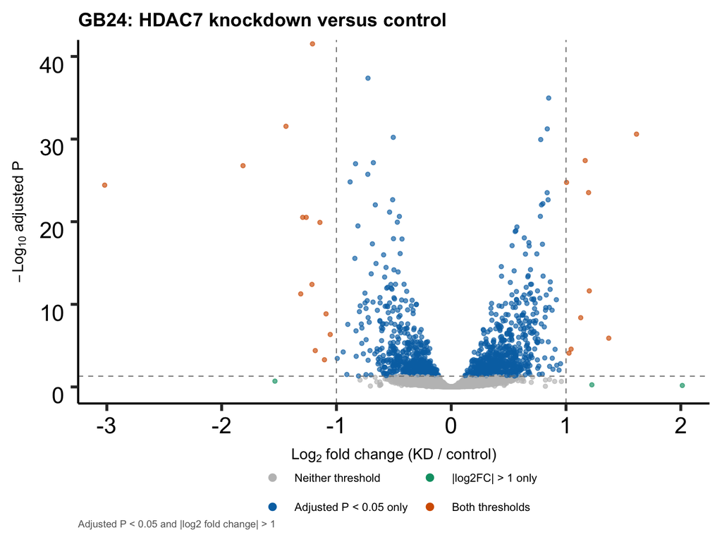

```r
print(p_GB24)
```

**The volcano plots suggest that the transcriptional response to HDAC7 inhibition differs across patient-derived GSC models, which is expected for sucha heterogeneous type of tunot. GB2 shows prominent changes in both directions, whereas GB11 displays a stronger pattern of increased expression. In GB24, many statistically significant changes fall below the |log2 fold change| > 1 threshold, indicating smaller expression shifts. These differences suggest that the magnitude and direction of the response differes with the genotype of cellular context. Pathway enrichment and comparison of shared genes can help identify which biological programs are consistently affected across models.**

### 4.2 MA Plot

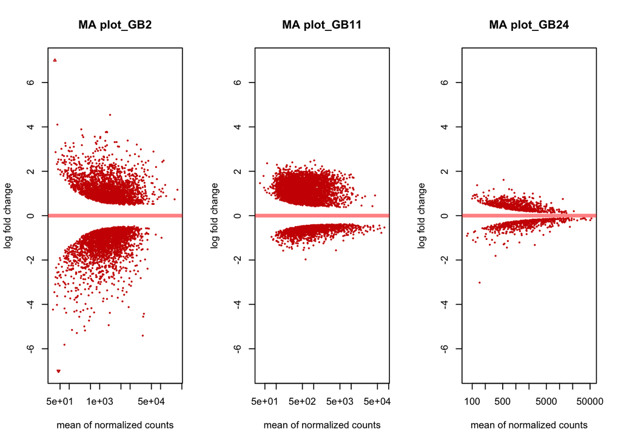

```r
## MA plot describes the differential expression by plotting log transformed expression values with mean average values, while volcano plot scales significance value at y axis and fold change at x axis

par(mfrow=c(1,3))


#Red points have adjusted p value < 0.1. We see that in general genes that are highly expressed, or have a high fold change, are DE.
plotMA(res_GB2_Sig_0.01, ylim=c(-7,7), main="MA plot_GB2")
plotMA(GB11_all_diff_expressed, ylim=c(-7,7), main="MA plot_GB11")
plotMA(GB24_all_diff_expressed, ylim=c(-7,7), main="MA plot_GB24")
```

### 4.3 Heatmap Clustering

### Heatmaps display the top 30 differentially expressed genes ranked by adjusted P-value within each GSC model. Regularized log-transformed expression values are centered across samples for each gene.

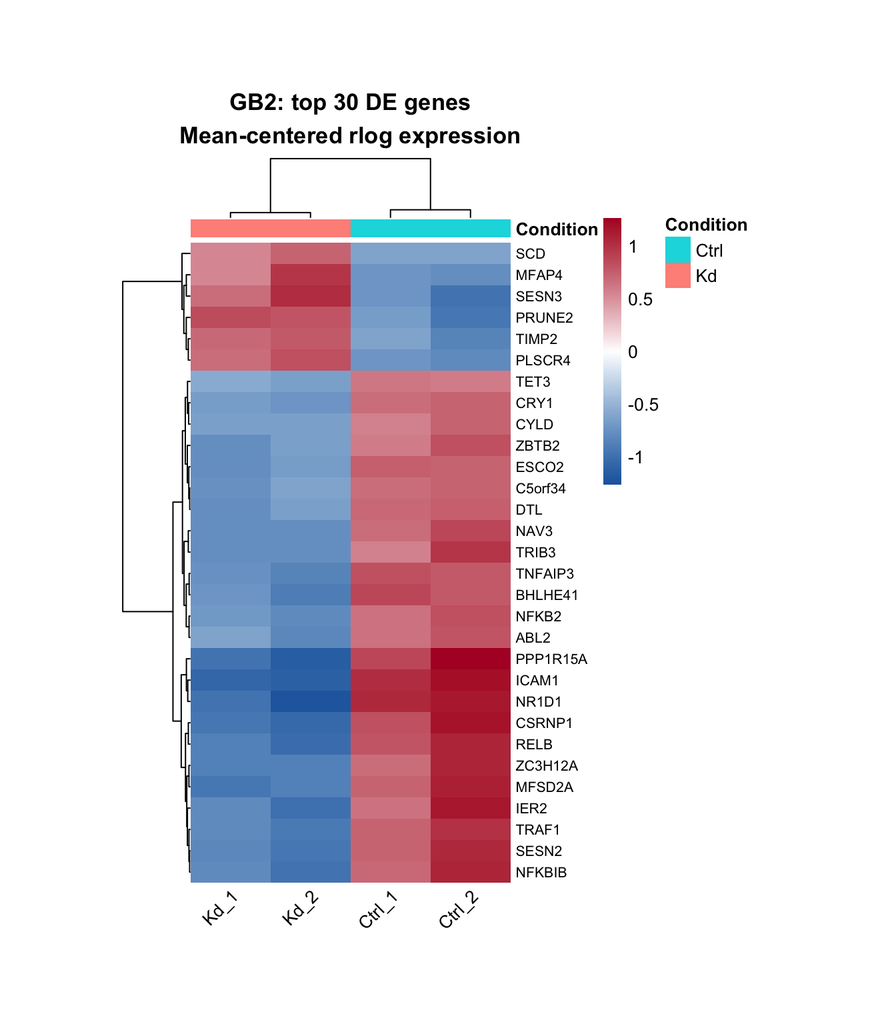

```r
library(pheatmap)

plot_gene_heatmap <- function(res, rld, condition_column, model,
                              n_genes = 30) {

  # Select significant genes and rank by adjusted P-value
  results_df <- as.data.frame(res)

  results_df <- results_df[
    !is.na(results_df$padj) &
      results_df$padj < 0.05 &
      is.finite(results_df$log2FoldChange),
    ,
    drop = FALSE
  ]

  results_df <- results_df[
    order(results_df$padj, -abs(results_df$log2FoldChange)),
    ,
    drop = FALSE
  ]

  # Match genes by name
  available_genes <- rownames(results_df)[
    rownames(results_df) %in% rownames(assay(rld))
  ]

  selected_genes <- head(available_genes, n_genes)

  if (length(selected_genes) < 2) {
    stop(paste(model, "has fewer than two significant genes to plot."))
  }

  expression_mat <- assay(rld)[selected_genes, , drop = FALSE]

  # Center each gene across samples
  expression_mat <- sweep(
    expression_mat, 1, rowMeans(expression_mat), "-"
  )

  # Annotate conditions
  condition <- as.character(colData(rld)[[condition_column]])

  annotation <- data.frame(
    Condition = factor(condition),
    row.names = colnames(expression_mat)
  )

  # Label replicates within each condition
  replicate_number <- ave(
    seq_along(condition),
    condition,
    FUN = seq_along
  )

  sample_labels <- paste0(condition, "_", replicate_number)

  # Symmetric color scale
  color_limit <- max(abs(expression_mat))

  if (!is.finite(color_limit) || color_limit == 0) {
    stop(paste(model, "has invalid or constant expression values."))
  }

  pheatmap(
    expression_mat,
    annotation_col = annotation,

    color = colorRampPalette(
      c("#2166AC", "white", "#B2182B")
    )(100),
    breaks = seq(-color_limit, color_limit, length.out = 101),

    cluster_rows = TRUE,
    cluster_cols = TRUE,
    clustering_distance_rows = "euclidean",
    clustering_distance_cols = "euclidean",
    clustering_method = "complete",

    labels_col = sample_labels,
    angle_col = "45",

    fontsize = 10,
    fontsize_row = 8,
    fontsize_col = 10,

    cellwidth = 45,
    cellheight = 12,
    treeheight_row = 35,
    treeheight_col = 30,
    border_color = NA,

    main = paste0(
      model, ": top ", length(selected_genes),
      " DE genes\nMean-centered rlog expression"
    )
  )
}

plot_gene_heatmap(res_GB2, rld_GB2, "exp.des_GB2", "GB2")
```

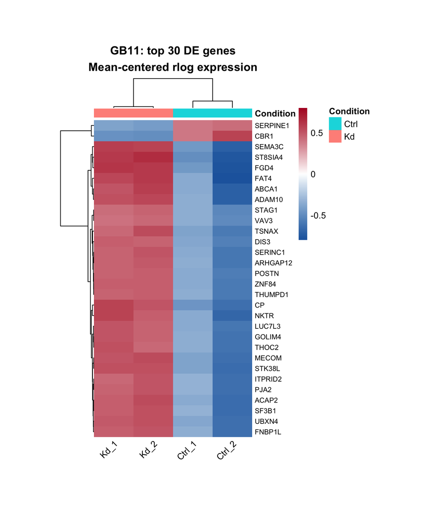

```r
plot_gene_heatmap(res_GB11, rld_GB11, "exp.des_GB11", "GB11")
```

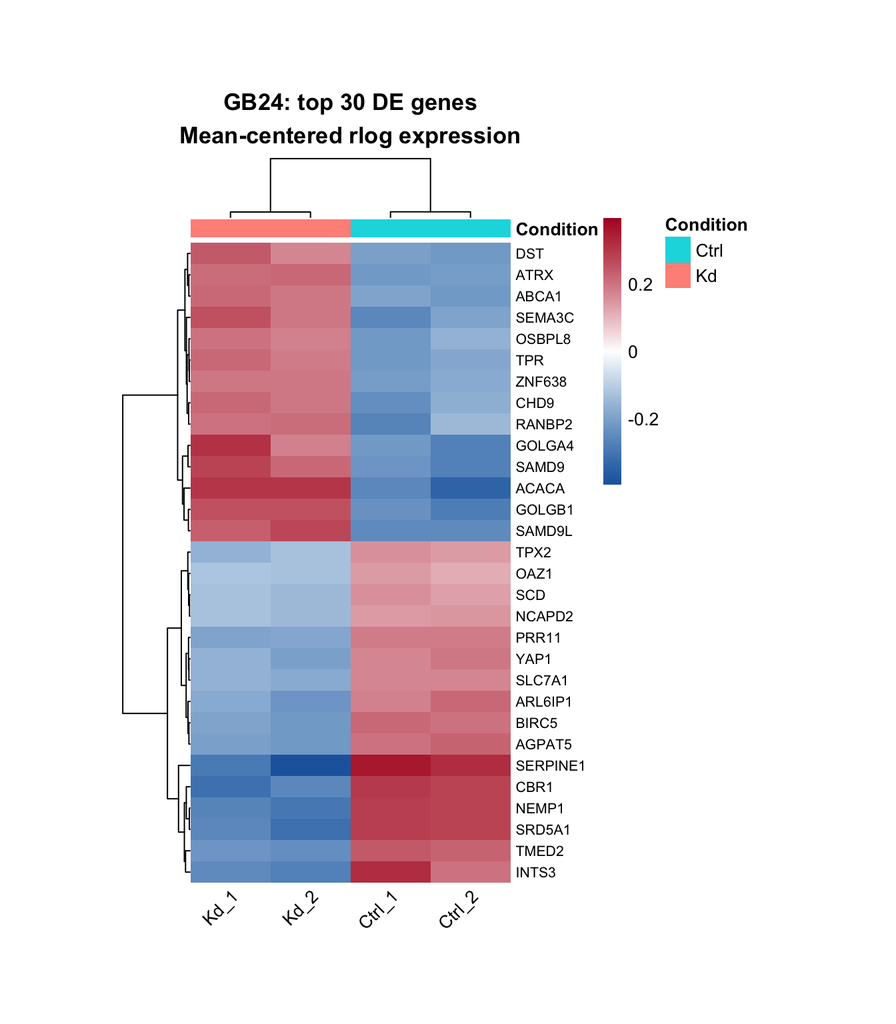

```r
plot_gene_heatmap(res_GB24, rld_GB24, "exp.des_GB24", "GB24")
```

## 5. Pathway Analysis

```r
library(clusterProfiler)
```

```r
library(enrichplot)
library(ggplot2)

# SET THE DESIRED ORGANISM HERE
library(org.Hs.eg.db)
HA = org.Hs.eg.db
```

### We will consider two ways for the pathways enrichment

[figure not shown]

```r
library(clusterProfiler)
library(enrichplot)
library(org.Hs.eg.db)
library(ggplot2)

run_go_gsea <- function(res, model) {

  results_df <- as.data.frame(res)
  results_df$gene <- rownames(results_df)

  # Use all genes with a valid Wald statistic
  results_df <- results_df[
    is.finite(results_df$stat) &
      !is.na(results_df$gene) &
      nzchar(results_df$gene),
    ,
    drop = FALSE
  ]

  # Keep one entry per gene symbol
  results_df <- results_df[
    order(abs(results_df$stat), decreasing = TRUE),
    ,
    drop = FALSE
  ]
  results_df <- results_df[!duplicated(results_df$gene), ]

  # Create a named, decreasingly ranked vector
  gene_list <- setNames(results_df$stat, results_df$gene)
  gene_list <- sort(gene_list, decreasing = TRUE)

  set.seed(123)

  gsea_result <- gseGO(
    geneList = gene_list,
    OrgDb = org.Hs.eg.db,
    keyType = "SYMBOL",
    ont = "ALL",
    minGSSize = 3,
    maxGSSize = 800,
    pvalueCutoff = 0.01,
    pAdjustMethod = "none",
    by = "fgsea",
    seed = TRUE,
    verbose = FALSE
  )

  # Handle models without significant enrichment
  if (nrow(as.data.frame(gsea_result)) == 0) {
    message(model, ": no GO terms meet the enrichment cutoff.")
    return(gsea_result)
  }

   print(
    dotplot(
      gsea_result,
      showCategory = 15,
      color = "p.adjust",
      font.size = 12
    ) +
      scale_y_discrete(
        labels = function(x) vapply(
          x,
          function(label) {
            paste(strwrap(label, width = 45), collapse = "\n")
          },
          character(1)
        )
      ) +
      labs(
        title = paste0(model, ": GO GSEA"),
        subtitle = "Genes ranked by DESeq2 Wald statistic",
        caption = "Nominal P < 0.01; no multiple-testing correction"
      ) +
      theme(
        plot.title = element_text(size = 19, face = "bold"),
        plot.subtitle = element_text(size = 14),
        axis.title = element_text(size = 15),
        axis.text.x = element_text(size = 13),
        axis.text.y = element_text(size = 12),
        legend.title = element_text(size = 14),
        legend.text = element_text(size = 12),
        plot.caption = element_text(size = 12, hjust = 0)
      )
  )

  return(gsea_result)
}

# Use full DESeq2 results
gse_GB2  <- run_go_gsea(res_GB2, "GB2")
```

```r
gse_GB11 <- run_go_gsea(res_GB11, "GB11")
```

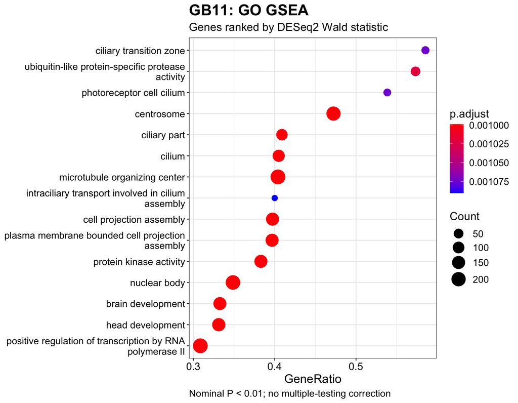

```r
gse_GB24 <- run_go_gsea(res_GB24, "GB24")
```

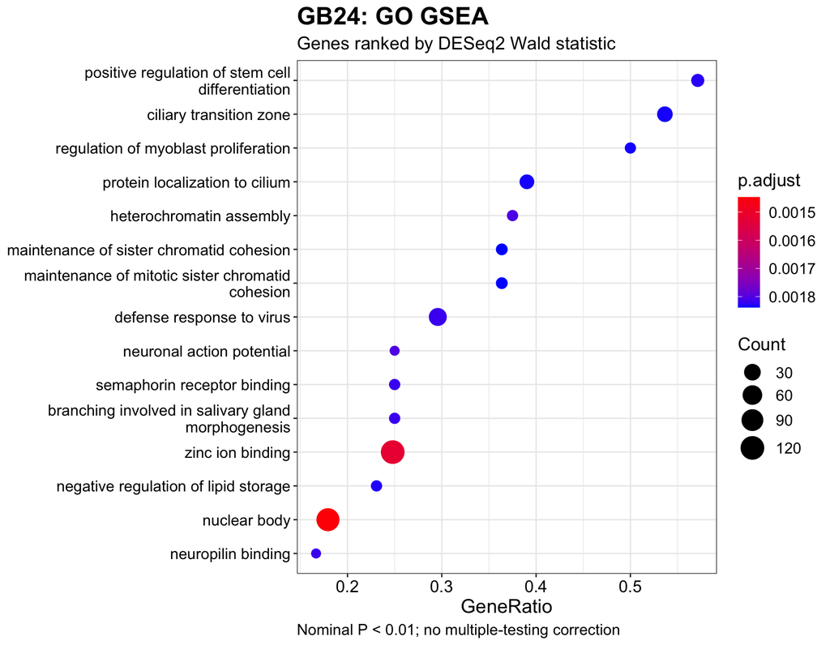

### B. Enrich GO method that focuses on the significant genes.

It answers whether genes associated with a particular biological process more common in my significant gene list than I would expect by chance?.

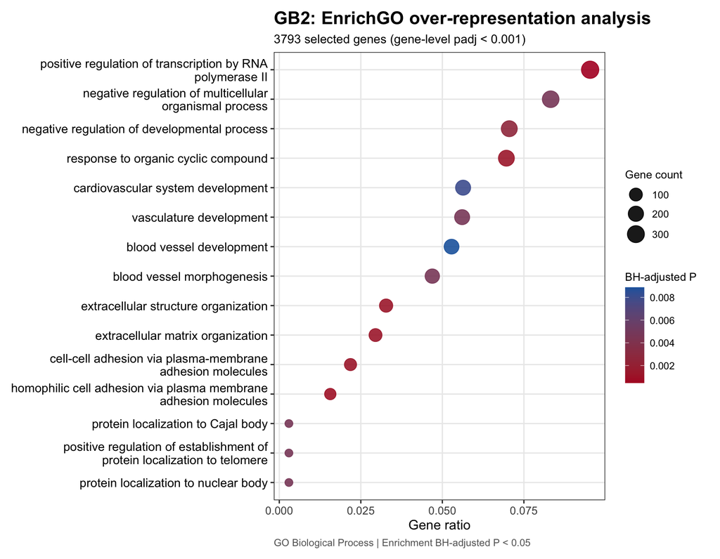

```r
run_go_ora <- function(res, model, gene_padj_cutoff = 0.05) {

  results_df <- as.data.frame(res)
  results_df$gene <- rownames(results_df)

  # Background: genes with valid adjusted P-values
  tested_genes <- results_df[
    !is.na(results_df$padj) &
      !is.na(results_df$gene) &
      nzchar(results_df$gene),
    ,
    drop = FALSE
  ]

  background_genes <- unique(tested_genes$gene)

  # Significant genes, including both expression directions
  significant_genes <- unique(
    tested_genes$gene[
      tested_genes$padj < gene_padj_cutoff
    ]
  )

  if (length(significant_genes) == 0) {
    message(model, ": no genes meet the selection threshold.")
    return(NULL)
  }

  ora_result <- enrichGO(
    gene = significant_genes,
    universe = background_genes,
    OrgDb = org.Hs.eg.db,
    keyType = "SYMBOL",
    ont = "BP",
    pAdjustMethod = "BH",
    pvalueCutoff = 1,
    qvalueCutoff = 1,
    minGSSize = 10,
    maxGSSize = 800
  )

  # Keep the full result object; apply the enrichment cutoff for plotting
  result_table <- as.data.frame(ora_result)

  enriched_terms <- result_table[
    !is.na(result_table$p.adjust) &
      result_table$p.adjust < 0.05,
    ,
    drop = FALSE
  ]

  if (nrow(enriched_terms) == 0) {

    print(
      ggplot() +
        annotate(
          "text", x = 0, y = 0,
          label = paste0(
            model,
            "\nNo GO Biological Process terms\n",
            "meet BH-adjusted P < 0.05"
          ),
          size = 5
        ) +
        xlim(-1, 1) +
        ylim(-1, 1) +
        theme_void()
    )

    return(ora_result)
  }

  # Display the 15 terms with the lowest adjusted P-values
  enriched_terms <- enriched_terms[
    order(enriched_terms$p.adjust),
    ,
    drop = FALSE
  ]

  top_terms <- head(enriched_terms, 15)

  # Convert GeneRatio from fractions to numeric values
  top_terms$GeneRatioNumeric <- vapply(
    strsplit(as.character(top_terms$GeneRatio), "/", fixed = TRUE),
    function(x) as.numeric(x[1]) / as.numeric(x[2]),
    numeric(1)
  )

  top_terms$Label <- vapply(
    top_terms$Description,
    function(x) paste(strwrap(x, width = 45), collapse = "\n"),
    character(1)
  )

  # Use GO IDs to keep terms distinct
  top_terms$ID <- factor(
    top_terms$ID,
    levels = top_terms$ID[order(top_terms$GeneRatioNumeric)]
  )

  term_labels <- setNames(
    top_terms$Label,
    as.character(top_terms$ID)
  )

  print(
    ggplot(
      top_terms,
      aes(x = GeneRatioNumeric, y = ID)
    ) +
      geom_point(
        aes(size = Count, color = p.adjust),
        alpha = 0.9
      ) +
      scale_y_discrete(labels = term_labels) +
      scale_color_gradient(
        low = "#B2182B",
        high = "#2166AC",
        name = "BH-adjusted P"
      ) +
      scale_size_continuous(
        range = c(3, 7),
        name = "Gene count"
      ) +
      labs(
        title = paste0(model, ": EnrichGO over-representation analysis"),
        subtitle = paste0(
          length(significant_genes),
          " selected genes (gene-level padj < ",
          gene_padj_cutoff, ")"
        ),
        x = "Gene ratio",
        y = NULL,
        caption = "GO Biological Process | Enrichment BH-adjusted P < 0.05"
      ) +
      theme_bw(base_size = 12) +
      theme(
        plot.title = element_text(size = 16, face = "bold"),
        plot.subtitle = element_text(size = 11),
        axis.title.x = element_text(size = 12),
        axis.text.x = element_text(size = 10),
        axis.text.y = element_text(size = 11, color = "black"),
        legend.title = element_text(size = 10),
        legend.text = element_text(size = 9),
        panel.grid.minor = element_blank(),
        plot.caption = element_text(
          size = 9, hjust = 0, color = "grey40"
        ),
        plot.margin = margin(10, 15, 10, 10)
      )
  )

  return(ora_result)
}

ego_GB2 <- run_go_ora(res_GB2, "GB2", gene_padj_cutoff = 0.001)
```

```r
ego_GB11 <- run_go_ora(res_GB11, "GB11", gene_padj_cutoff = 0.001)
```

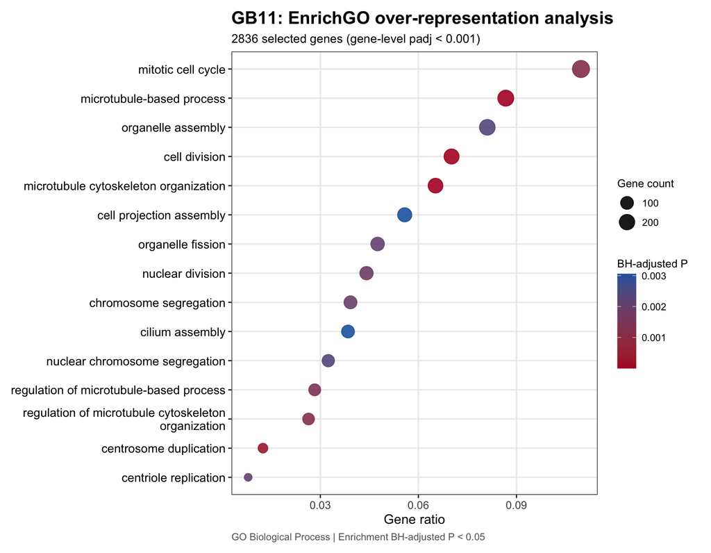

```r
ego_GB24 <- run_go_ora(res_GB24, "GB24", gene_padj_cutoff = 0.001)
```

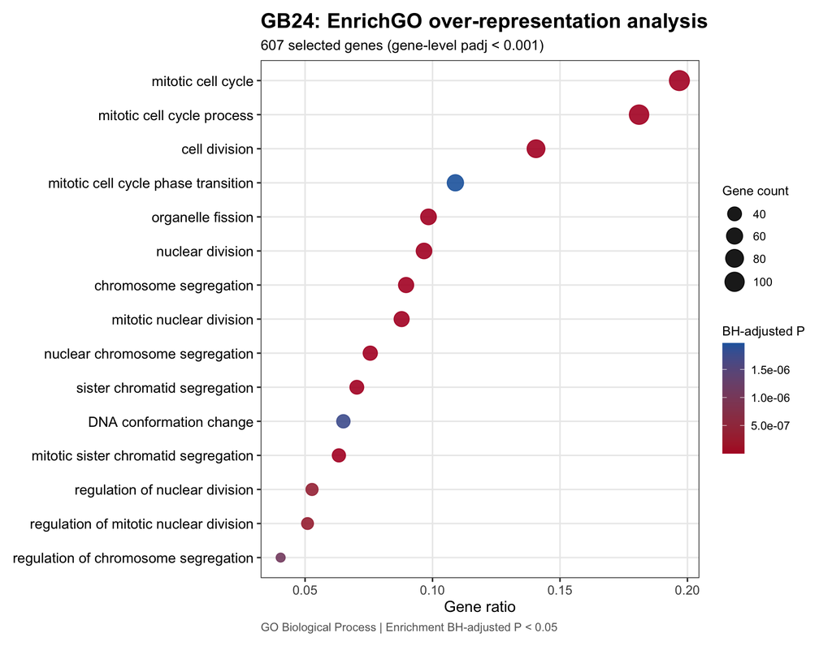

**EnrichGO analysis highlights distinct biological themes following HDAC7 knockdown. In GB11 and GB24, differentially expressed genes are enriched for cell-cycle and mitotic processes, including nuclear division and regulation of mitosis. GB11 additionally shows enrichment for microtubule and cytoskeletal organization, while GB24 emphasizes chromosome segregation and cell-cycle phase transitions. Together, these results implicate proliferation-related transcriptional programs in the response to HDAC7 depletion. In GB2, the displayed terms emphasize transcriptional regulation, developmental programs, extracellular matrix organization, and cell–cell adhesion. This suggests a broader response involving cellular identity and interactions with the extracellular environment. Enrichment of vascular-development terms reflects changes in genes annotated to these programs and does not by itself demonstrate blood-vessel formation.**

### Another GSEA enrichemnt visualization

Here, I used significant genes ranked by decreasing log2 fold change. Gene-level adjusted P-value cutoffs are 0.001 for GB2 and 0.01 for GB11 and GB24. The analysis includes Biological Process, Molecular Function, and Cellular Component categories, with gene-set sizes of 3–800 genes. Enriched terms were retained at nominal P <0.01 without multiple-testing correction and visualized using enrichment maps to highlight relationships among GO terms.

```r
# reading in data from deseq2
original_gene_list_GB2 <- res_GB2_Sig_0.001$log2FoldChange


# name the vector
names(original_gene_list_GB2) <- row.names(res_GB2_Sig_0.001)
#write.csv(original_gene_list_GB2, file= "GB2_Sig_0.001.csv", row.names = T)


# sort the list in decreasing order (required for clusterProfiler)
gene_list_GB2 = sort(original_gene_list_GB2, decreasing = TRUE)

gse_GB2 <- gseGO(geneList=gene_list_GB2,
             ont ="ALL",
             keyType = "SYMBOL",
             nPerm = 1000,
             minGSSize = 3,
             maxGSSize = 800,
             pvalueCutoff = 0.01,
             verbose = TRUE,
             OrgDb = HA,
             pAdjustMethod = "none")
```

```
## preparing geneSet collections...
```

```
## GSEA analysis...
```

```
## leading edge analysis...
```

```
## done...
```

```r
require(DOSE)
```

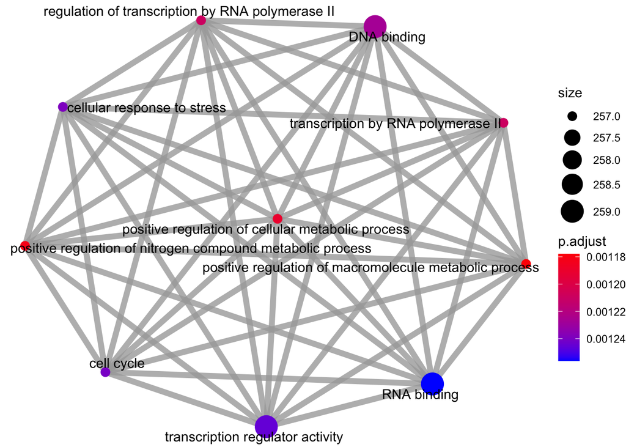

```r
emapplot(gse_GB2, showCategory = 10)
```

```r
# reading in data from deseq2
#GB11
# reading in data from deseq2
original_gene_list_GB11 <- res_GB11_Sig_0.01$log2FoldChange

# name the vector
names(original_gene_list_GB11) <- row.names(res_GB11_Sig_0.01)

# sort the list in decreasing order (required for clusterProfiler)
gene_list_GB11 = sort(original_gene_list_GB11, decreasing = TRUE)

gse_GB11 <- gseGO(geneList=gene_list_GB11,
             ont ="ALL",
             keyType = "SYMBOL",
             nPerm = 1000,
             minGSSize = 3,
             maxGSSize = 800,
             pvalueCutoff = 0.01,
             verbose = TRUE,
             OrgDb = HA,
             pAdjustMethod = "none")
```

```
## preparing geneSet collections...
```

```
## GSEA analysis...
```

```
## leading edge analysis...
```

```
## done...
```

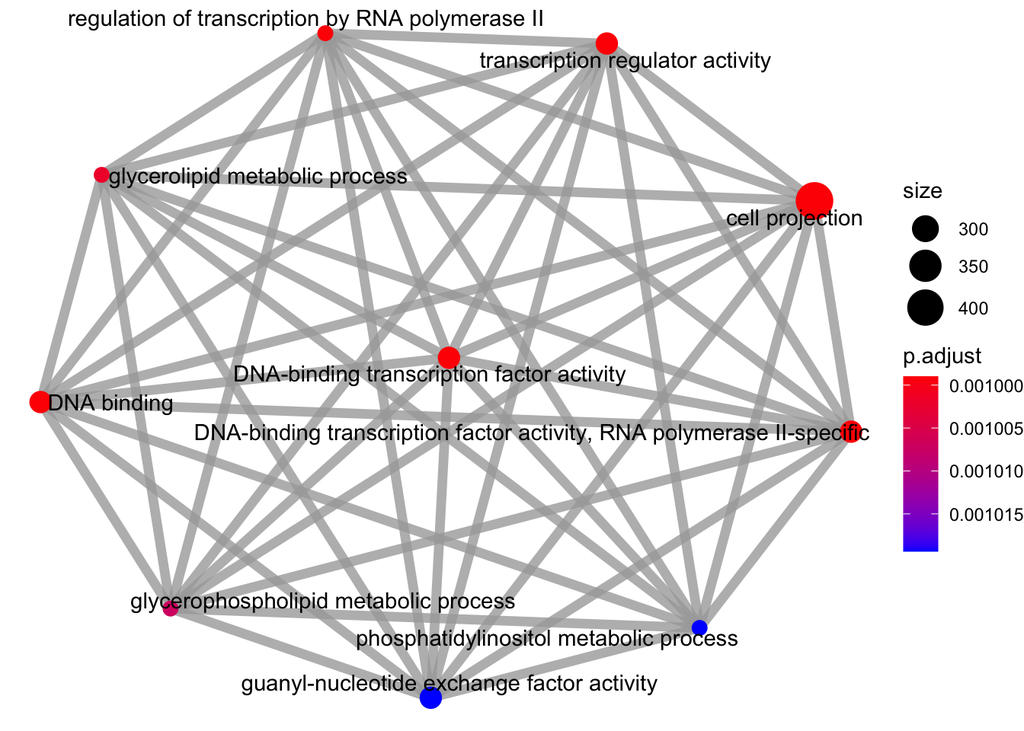

```r
emapplot(gse_GB11, showCategory = 10, color = "p.adjust",)
```

```r
#GB24
# reading in data from deseq2
original_gene_list_GB24 <- res_GB24_Sig_0.01$log2FoldChange

# name the vector
names(original_gene_list_GB24) <- row.names(res_GB24_Sig_0.01)

# sort the list in decreasing order (required for clusterProfiler)
gene_list_GB24 = sort(original_gene_list_GB24, decreasing = TRUE)

gse_GB24 <- gseGO(geneList=gene_list_GB24,
             ont ="ALL",
             keyType = "SYMBOL",
             nPerm = 1000,
             minGSSize = 3,
             maxGSSize = 800,
             pvalueCutoff = 0.01,
             verbose = TRUE,
             OrgDb = HA,
             pAdjustMethod = "none")
```

```
## preparing geneSet collections...
```

```
## GSEA analysis...
```

```
## leading edge analysis...
```

```
## done...
```

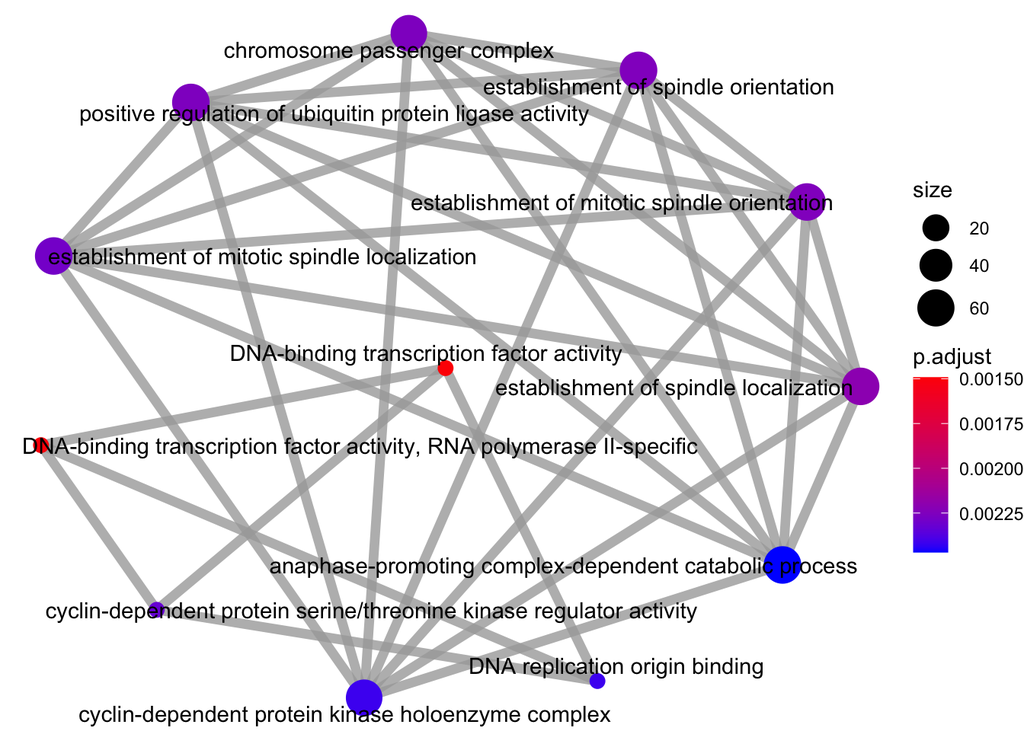

```r
emapplot(gse_GB24, showCategory = 12)
```

## 6. Expression of selected genes of interest

### Expression of selected stemness-associated genes accross the three GSC Models

Normalized RNA-seq counts were examined for a selected panel of stemness-associated genes in GB2, GB11, and GB24 to assess their expression following HDAC7 knockdown.Dots represent individual samples, and black diamonds indicate group means. Each gene has its own Y-axis scale to make differences between conditions easier to visualize. Statistical significance should be assessed using the corresponding DESeq2 results.

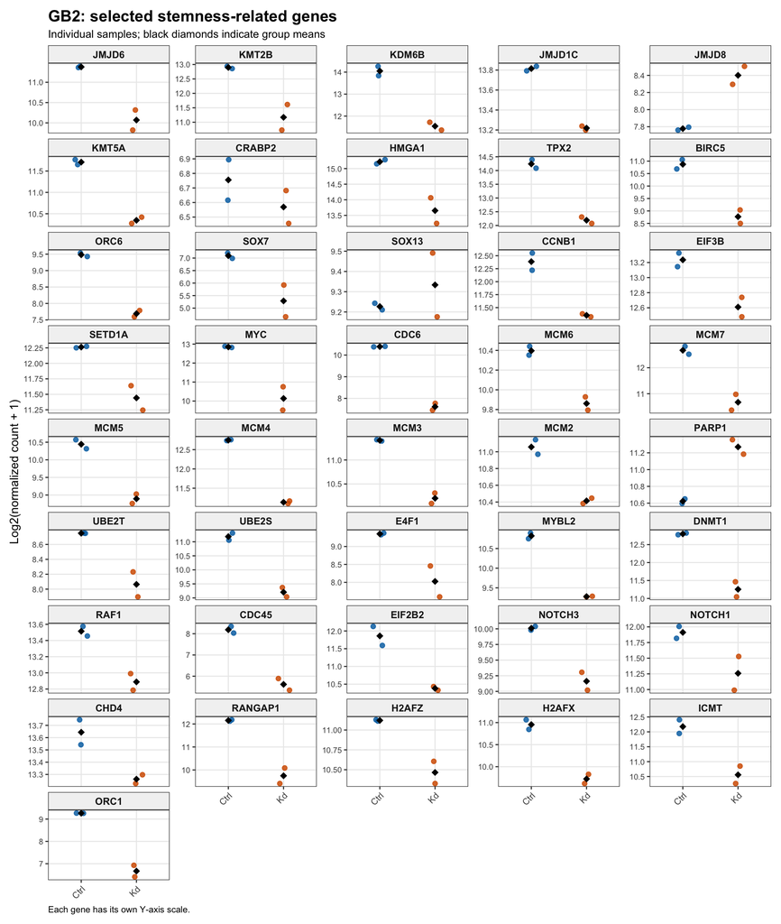

```r
# Use KDM6B for JMJD3
stemness_genes <- c(
  "JMJD6", "KMT2B", "KDM6B", "JMJD1C", "JMJD8",
  "KMT5A", "CRABP2", "HMGA1", "TPX2", "BIRC5",
  "ORC6", "SOX7", "SOX13", "CCNB1", "EIF3B",
  "SETD1A", "MYC", "CDC6", "MCM6", "MCM7",
  "MCM5", "MCM4", "MCM3", "MCM2", "PARP1",
  "UBE2T", "UBE2S", "E4F1", "MYBL2", "DNMT1",
  "RAF1", "CDC45", "EIF2B2", "NOTCH3", "NOTCH1",
  "CHD4", "RANGAP1", "H2AFZ", "H2AFX", "ICMT", "ORC1"
)

plot_panel_counts <- function(dds, condition_column, model,
                              genes = stemness_genes) {

  normalized_counts <- counts(dds, normalized = TRUE)

  present_genes <- genes[genes %in% rownames(normalized_counts)]
  missing_genes <- setdiff(genes, present_genes)

  if (length(missing_genes) > 0) {
    message(
      model, ": genes not found: ",
      paste(missing_genes, collapse = ", ")
    )
  }

  if (length(present_genes) == 0) {
    stop(model, ": none of the requested genes were found.")
  }

  selected_counts <- normalized_counts[
    present_genes, , drop = FALSE
  ]

  # Convert counts to a table with one row per gene and sample
  plot_data <- data.frame(
    Gene = rep(rownames(selected_counts),
               times = ncol(selected_counts)),
    Sample = rep(colnames(selected_counts),
                 each = nrow(selected_counts)),
    NormalizedCount = as.vector(selected_counts)
  )

  sample_condition <- as.character(
    colData(dds)[[condition_column]]
  )
  names(sample_condition) <- colnames(dds)

  plot_data$Condition <- factor(
    sample_condition[plot_data$Sample],
    levels = unique(sample_condition)
  )

  plot_data$Gene <- factor(
    plot_data$Gene,
    levels = present_genes
  )

  plot_data$Model <- model
  plot_data$Log2Count <- log2(plot_data$NormalizedCount + 1)

  p <- ggplot(
    plot_data,
    aes(x = Condition, y = Log2Count, color = Condition)
  ) +
    geom_point(
      position = position_jitter(width = 0.12, height = 0,
                                 seed = 123),
      size = 2,
      alpha = 0.85
    ) +
    stat_summary(
      fun = mean,
      geom = "point",
      shape = 18,
      size = 3,
      color = "black"
    ) +
    facet_wrap(~ Gene, ncol = 5, scales = "free_y") +
    scale_color_manual(
      values = rep(
        c("#0072B2", "#D55E00"),
        length.out = nlevels(plot_data$Condition)
      )
    ) +
    labs(
      title = paste0(model, ": selected stemness-related genes"),
      subtitle = "Individual samples; black diamonds indicate group means",
      x = NULL,
      y = "Log2(normalized count + 1)",
      caption = "Each gene has its own Y-axis scale."
    ) +
    theme_bw(base_size = 11) +
    theme(
      plot.title = element_text(size = 16, face = "bold"),
      plot.subtitle = element_text(size = 11),
      strip.text = element_text(size = 10, face = "bold"),
      strip.background = element_rect(fill = "grey95"),
      axis.text.x = element_text(
        size = 9, angle = 45, hjust = 1
      ),
      axis.text.y = element_text(size = 8),
      axis.title.y = element_text(size = 12),
      panel.grid.minor = element_blank(),
      legend.position = "none",
      plot.caption = element_text(size = 9, hjust = 0),
      plot.margin = margin(10, 10, 10, 10)
    )

  print(p)
  return(plot_data)
}

counts_GB2 <- plot_panel_counts(
  dds_GB2, "exp.des_GB2", "GB2"
)
```

```
## GB11: genes not found: SOX7
```

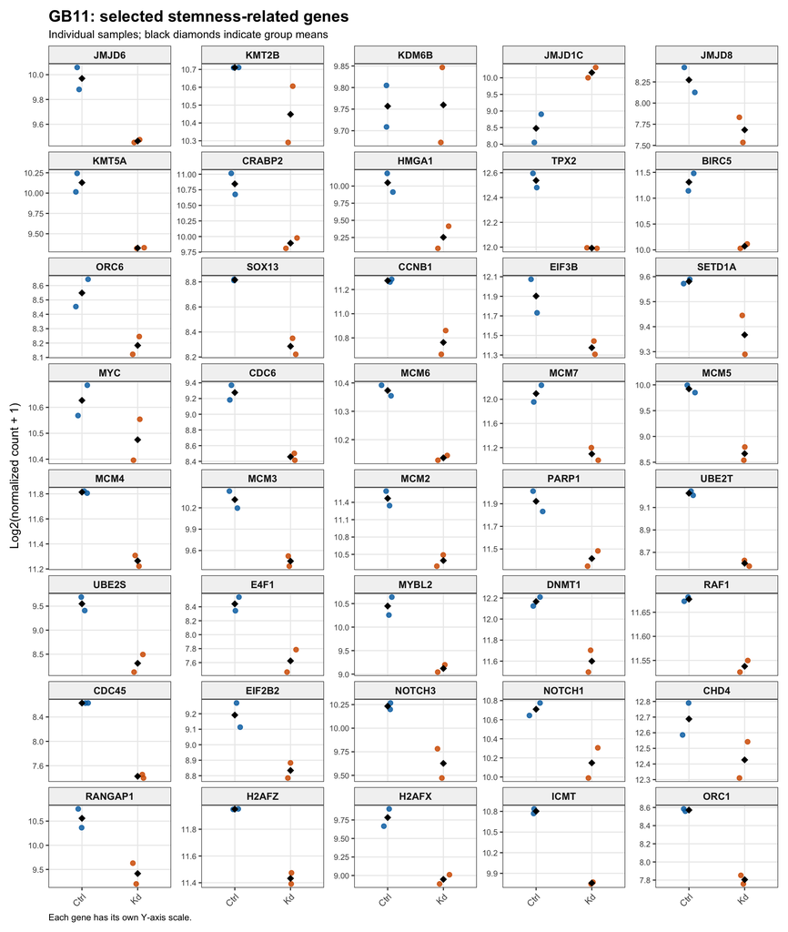

```r
counts_GB11 <- plot_panel_counts(
  dds_GB11, "exp.des_GB11", "GB11"
)
```

```
## GB24: genes not found: SOX7
```

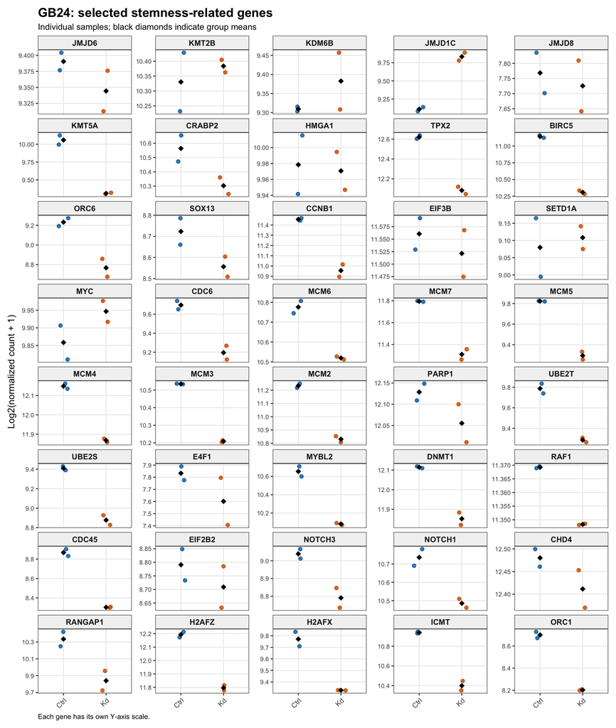

```r
counts_GB24 <- plot_panel_counts(
  dds_GB24, "exp.des_GB24", "GB24"
)
```

```r
# Combined table of normalized counts
stemness_counts <- rbind(
  counts_GB2, counts_GB11, counts_GB24
)
```

**HDAC7 knockdown is associated with a coordinated decrease in expression of many genes in the selected panel across GB2, GB11, and GB24. Shared decreases include MCM2–7, CDC6, CDC45, ORC1, and ORC6, alongside TPX2, BIRC5, CCNB1, and MYBL2. This pattern is consistent with reduced DNA replication and mitotic activity, supporting the cell-cycle themes identified in the GO enrichment analysis.Also, NOTCH1, NOTCH3, KMT5A, DNMT1, and CHD4 also show lower expression across the three models, suggesting that the response extends beyond proliferation to include changes in stemness-associated signaling and chromatin regulation.Together, these observations are consistent with disruption of proliferative and stemness-associated programs following HDAC7 depletion**

## Additional analyses

### Transcrption factor enrichment analysis:

**We put the genes that were downregulated by the HDAC7 knockdown from the 3GSCs on the ChEA3 webtool, https://maayanlab.cloud/chea3/**

### Stemness enrichment and phenotype analysis:

**We put the genes that were downregulated by the HDAC7 knockdown from the 3 GSCs on the StemChecker webtool, http://stemchecker.sysbiolab.eu**

### Stemness gene signature analysis:

**We put the genes that were downregulated by the HDAC7 knockdown from the 3 GSCs on the GSEA software**

## Final interpretaion:

**Across the three patient-derived GSC models, HDAC7 knockdown is associated with transcriptional changes involving cell-cycle regulation, DNA replication, and stemness-associated genes. GO enrichment highlights mitotic and chromosome-segregation processes, particularly in GB11 and GB24. Consistent with these findings, the selected-gene plots show lower expression of replication and cell-cycle genes, including MCM2–7, CDC6, CDC45, CCNB1, and BIRC5, across all three models.** **The response also varies between models. GB2 enrichment emphasizes extracellular matrix organization, adhesion, and developmental programs, while genes such as MYC and JMJD1C show different expression responses across the models. These observations suggest a shared proliferation-related response alongside model-specific transcriptional changes.** **Together, the results support a role for HDAC7 in maintaining transcriptional programs associated with GSC proliferation and stemness. RNA-seq alone does not establish direct regulation or loss of self-renewal; those conclusions require functional evidence. The original filtered GSEA, which uses uncorrected enrichment P-values, should be treated as exploratory, with greater weight placed on the BH-corrected analyses and statistically supported gene-level changes.**

### References:

*https://bioconductor.org/packages/release/workflows/vignettes/rnaseqGene/inst/doc/rnaseqGene.html* *http://bioconnector.github.io/bims8382/r-rnaseq-airway.html* *http://stemchecker.sysbiolab.eu/*